# **COSC2789 - Practical Data Science**

##### *Lasso L1 Regularization - Regression Task*

```python
selected_features_l1_reg, coef_series_reg, coef_df_reg = lasso_feature_selection(X_train_reg, y_train_reg, alpha=10)
print(f"Selected features: \n {selected_features_l1_reg}\n")
print(f"Coef serires: \n {coef_df_reg}\n")
```

```
Selected features:
 ['Administrative', 'Administrative_Duration', 'Informational', 'Informational_Duration', 'ProductRelated', 'BounceRates', 'ExitRates', 'PageValues', 'SpecialDay', 'Month', 'Browser', 'Region', 'VisitorType', 'Revenue']

Coef serires:
                    features        coeff
8                SpecialDay   -52.344828
5               BounceRates   -25.672540
12                   Region    -6.015812
0            Administrative    -5.675220
14              VisitorType    -1.570268
10         OperatingSystems    -0.000000
15                  Weekend    -0.000000
13              TrafficType    -0.000000
11                  Browser     2.316149
2             Informational     7.894830
9                     Month     8.040614
7                PageValues    17.911668
1   Administrative_Duration    23.798946
16                  Revenue    31.444203
3    Informational_Duration    71.272566
6                 ExitRates   313.826672
4            ProductRelated  1366.965000
```

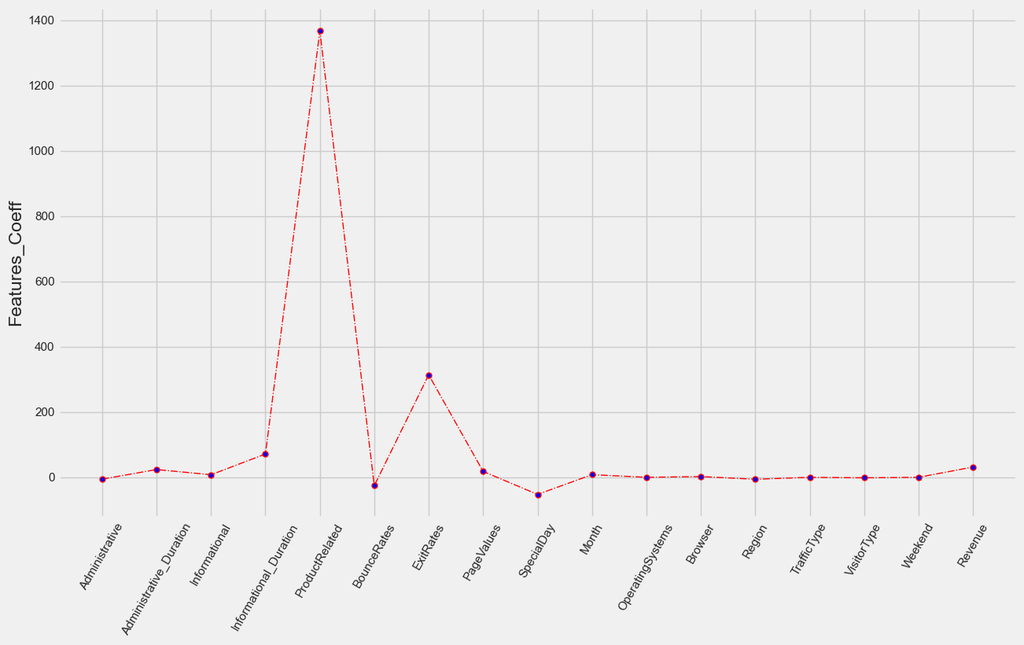

```python
# Lets plot the coeff with features
plt.figure(figsize=(14,8))
plt.plot(range(len(X_train_reg.columns)), coef_series_reg, color='red', linestyle='dashdot', linewidth = 1,marker='o',
         markerfacecolor='blue', markersize=5)
plt.xticks(range(len(X_train_reg.columns)),X_train_reg.columns,rotation=60)
plt.ylabel("Features_Coeff")
plt.show()
```

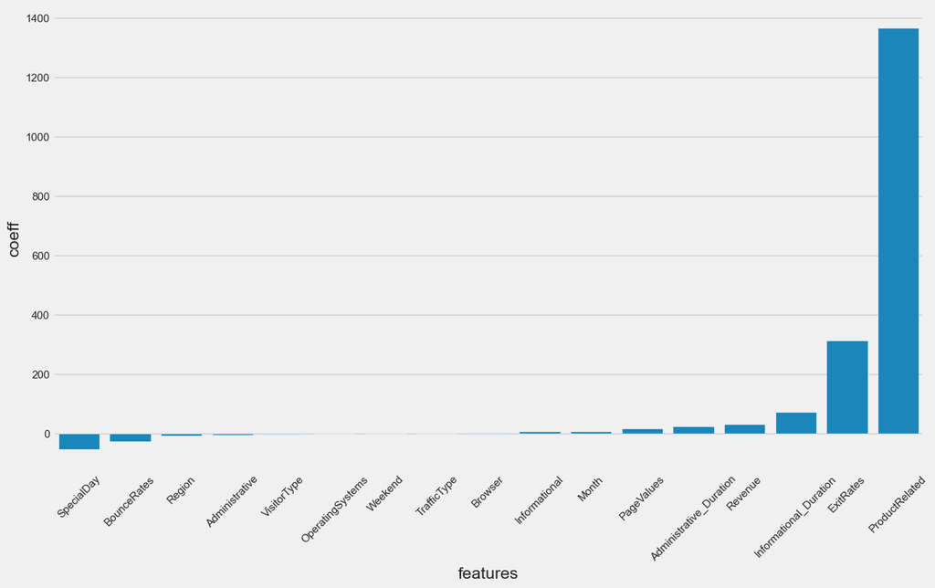

```python
# Use Bar chart to show coeff
plt.figure(figsize=(14,8))
# plot the feature coeff in bars.
plt.xticks(rotation=45)
sns.barplot(x="features",y= "coeff", data=coef_df_reg)
```

```python
rfr = RandomForestRegressor(random_state=42)
etr = ExtraTreesRegressor(random_state=42)
gbr = GradientBoostingRegressor(random_state=42)
dtr = DecisionTreeRegressor(random_state=42)

rfr.fit(X_train_reg[selected_features_l1_reg], y_train_reg)
etr.fit(X_train_reg[selected_features_l1_reg], y_train_reg)
gbr.fit(X_train_reg[selected_features_l1_reg], y_train_reg)
dtr.fit(X_train_reg[selected_features_l1_reg], y_train_reg)

mse_rfr = mean_squared_error(y_test_reg, rfr.predict(X_test_reg[selected_features_l1_reg]))
mse_etr = mean_squared_error(y_test_reg, etr.predict(X_test_reg[selected_features_l1_reg]))
mse_gbr = mean_squared_error(y_test_reg, gbr.predict(X_test_reg[selected_features_l1_reg]))
mse_dtr = mean_squared_error(y_test_reg, dtr.predict(X_test_reg[selected_features_l1_reg]))

print(f"MSE of Random Forest: {mse_rfr}")
print(f"MSE of Extra Trees: {mse_etr}")
print(f"MSE of Gradient Boosting: {mse_gbr}")
print(f"MSE of Decision Tree: {mse_dtr}")
```

```
MSE of Random Forest: 737653.4435280281
MSE of Extra Trees: 754659.1365994589
MSE of Gradient Boosting: 706363.6119240413
MSE of Decision Tree: 1609783.9975047195
```

Selected features from Lasso L1 Regularization are:

- **Administrative**
- **Administrative_Duration**
- **Informational**
- **Informational_Duration**
- **ProductRelated**
- **BounceRates**
- **ExitRates**
- **PageValues**
- **SpecialDay**
- **Month**
- **Browser**
- **Region**
- **VisitorType**
- **Revenue**

#### **Tree Based**

Tree-based methods are a popular and effective approach for feature selection in machine learning. These methods, such as Decision Trees, Random Forests, and Gradient Boosting Machines (e.g., XGBoost, LightGBM), inherently evaluate the importance of features during the model training process. They work by splitting the data at each node based on the feature that provides the best separation of the target variable, often measured using criteria like Gini impurity or information gain. Features that contribute more to these splits are considered more important.

##### *Tree Based - Classification Task*

```python
rfc = RandomForestClassifier(random_state=42)
etc = ExtraTreesClassifier(random_state=42)
gbc = GradientBoostingClassifier(random_state=42)
dtc = DecisionTreeClassifier(random_state=42)

rfc.fit(X_train_clf, y_train_clf)
etc.fit(X_train_clf, y_train_clf)
gbc.fit(X_train_clf, y_train_clf)
dtc.fit(X_train_clf, y_train_clf)

featureImportance_clf = [(features,rfcImportance, etcImportance, gbcImportance, dtcImportance) for features, rfcImportance, etcImportance, gbcImportance, dtcImportance in zip(X_train_clf.columns,rfc.feature_importances_,etc.feature_importances_,gbc.feature_importances_,dtc.feature_importances_)]
featureImportance_clf = pd.DataFrame(featureImportance_clf,columns=['features','Random Forest Feature Importance', 'Extra Trees Feature Importance', 'Gradient Boosting Feature Importance', 'Decision Tree Feature Importance'])
featureImportance_clf.sort_values(by=['Random Forest Feature Importance', 'Extra Trees Feature Importance', 'Gradient Boosting Feature Importance', 'Decision Tree Feature Importance'],ascending=False, inplace=True)
featureImportance_clf.head(10)
```

|  | features | Random Forest Feature Importance | Extra Trees Feature Importance | Gradient Boosting Feature Importance | Decision Tree Feature Importance |
| --- | --- | --- | --- | --- | --- |
| 8 | PageValues | 0.370346 | 0.341806 | 0.762481 | 0.426767 |
| 7 | ExitRates | 0.083440 | 0.067487 | 0.023900 | 0.063544 |
| 5 | ProductRelated_Duration | 0.074760 | 0.057624 | 0.018437 | 0.060687 |
| 17 | Total_Duration | 0.074186 | 0.054358 | 0.016580 | 0.054010 |
| 4 | ProductRelated | 0.062424 | 0.058168 | 0.023219 | 0.059905 |
| 1 | Administrative_Duration | 0.054148 | 0.044505 | 0.012749 | 0.058723 |
| 6 | BounceRates | 0.049969 | 0.050088 | 0.035600 | 0.077191 |
| 10 | Month | 0.038929 | 0.046990 | 0.047931 | 0.034577 |
| 0 | Administrative | 0.038766 | 0.048999 | 0.027618 | 0.038229 |
| 13 | Region | 0.028082 | 0.040065 | 0.001225 | 0.024062 |

```python
selected_features_tree_based_clf = featureImportance_clf['features'].head(10).tolist()
selected_features_tree_based_clf
```

```
['PageValues',
 'ExitRates',
 'ProductRelated_Duration',
 'Total_Duration',
 'ProductRelated',
 'Administrative_Duration',
 'BounceRates',
 'Month',
 'Administrative',
 'Region']
```

```python
rfc = RandomForestClassifier(random_state=42)
etc = ExtraTreesClassifier(random_state=42)
gbc = GradientBoostingClassifier(random_state=42)
dtc = DecisionTreeClassifier(random_state=42)

rfc.fit(X_train_clf[selected_features_tree_based_clf], y_train_clf)
etc.fit(X_train_clf[selected_features_tree_based_clf], y_train_clf)
gbc.fit(X_train_clf[selected_features_tree_based_clf], y_train_clf)
dtc.fit(X_train_clf[selected_features_tree_based_clf], y_train_clf)

accuracy_rfc = accuracy_score(y_test_clf, rfc.predict(X_test_clf[selected_features_tree_based_clf]))
accuracy_etc = accuracy_score(y_test_clf, etc.predict(X_test_clf[selected_features_tree_based_clf]))
accuracy_gbc = accuracy_score(y_test_clf, gbc.predict(X_test_clf[selected_features_tree_based_clf]))
accuracy_dtc = accuracy_score(y_test_clf, dtc.predict(X_test_clf[selected_features_tree_based_clf]))

print(f"Accuracy of Random Forest: {accuracy_rfc}")
print(f"Accuracy of Extra Trees: {accuracy_etc}")
print(f"Accuracy of Gradient Boosting: {accuracy_gbc}")
print(f"Accuracy of Decision Tree: {accuracy_dtc}")
```

```
Accuracy of Random Forest: 0.9086439983613274
Accuracy of Extra Trees: 0.9070053256861942
Accuracy of Gradient Boosting: 0.9143793527242933
Accuracy of Decision Tree: 0.8615321589512495
```

Selected features from Tree-based selection are:

- **PageValues**
- **ExitRates**
- **ProductRelated_Duration**
- **Total_Duration**
- **ProductRelated**
- **Administrative_Duration**
- **BounceRates**
- **Month**
- **Administrative**
- **Region**

##### *Tree Based - Regresison Task*

```python
rfr = RandomForestRegressor(random_state=42)
etr = ExtraTreesRegressor(random_state=42)
gbr = GradientBoostingRegressor(random_state=42)
dtr = DecisionTreeRegressor(random_state=42)

rfr.fit(X_train_reg, y_train_reg)
etr.fit(X_train_reg, y_train_reg)
gbr.fit(X_train_reg, y_train_reg)
dtr.fit(X_train_reg, y_train_reg)

featureImportance_reg = [(features,rfrImportance, etrImportance, gbrImportance, dtrImportance) for features, rfrImportance, etrImportance, gbrImportance, dtrImportance in zip(X_train_reg.columns,rfr.feature_importances_,etr.feature_importances_,gbr.feature_importances_,dtr.feature_importances_)]
featureImportance_reg = pd.DataFrame(featureImportance_reg,columns=['features','Random Forest Feature Importance', 'Extra Trees Feature Importance', 'Gradient Boosting Feature Importance', 'Decision Tree Feature Importance'])
featureImportance_reg.sort_values(by=['Random Forest Feature Importance', 'Extra Trees Feature Importance', 'Gradient Boosting Feature Importance', 'Decision Tree Feature Importance'],ascending=False, inplace=True)
featureImportance_reg.head(10)
```

|  | features | Random Forest Feature Importance | Extra Trees Feature Importance | Gradient Boosting Feature Importance | Decision Tree Feature Importance |
| --- | --- | --- | --- | --- | --- |
| 4 | ProductRelated | 0.707239 | 0.600811 | 0.825422 | 0.673826 |
| 1 | Administrative_Duration | 0.100620 | 0.064850 | 0.064236 | 0.168657 |
| 3 | Informational_Duration | 0.047068 | 0.101398 | 0.075218 | 0.013024 |
| 6 | ExitRates | 0.033383 | 0.026567 | 0.013218 | 0.036134 |
| 5 | BounceRates | 0.020993 | 0.034845 | 0.001361 | 0.019506 |
| 9 | Month | 0.014473 | 0.019275 | 0.002718 | 0.014773 |
| 2 | Informational | 0.011955 | 0.042112 | 0.004489 | 0.007087 |
| 0 | Administrative | 0.011721 | 0.014889 | 0.007284 | 0.011419 |
| 13 | TrafficType | 0.011124 | 0.017531 | 0.001056 | 0.011022 |
| 12 | Region | 0.010971 | 0.015491 | 0.000498 | 0.013416 |

```python
selected_features_tree_based_reg = featureImportance_reg['features'].head(10).tolist()
selected_features_tree_based_reg
```

```
['ProductRelated',
 'Administrative_Duration',
 'Informational_Duration',
 'ExitRates',
 'BounceRates',
 'Month',
 'Informational',
 'Administrative',
 'TrafficType',
 'Region']
```

```python
rfr = RandomForestRegressor(random_state=42)
etr = ExtraTreesRegressor(random_state=42)
gbr = GradientBoostingRegressor(random_state=42)
dtr = DecisionTreeRegressor(random_state=42)

rfr.fit(X_train_reg[selected_features_tree_based_reg], y_train_reg)
etr.fit(X_train_reg[selected_features_tree_based_reg], y_train_reg)
gbr.fit(X_train_reg[selected_features_tree_based_reg], y_train_reg)
dtr.fit(X_train_reg[selected_features_tree_based_reg], y_train_reg)

mse_rfr = mean_squared_error(y_test_reg, rfr.predict(X_test_reg[selected_features_tree_based_reg]))
mse_etr = mean_squared_error(y_test_reg, etr.predict(X_test_reg[selected_features_tree_based_reg]))
mse_gbr = mean_squared_error(y_test_reg, gbr.predict(X_test_reg[selected_features_tree_based_reg]))
mse_dtr = mean_squared_error(y_test_reg, dtr.predict(X_test_reg[selected_features_tree_based_reg]))

print(f"MSE of Random Forest: {mse_rfr}")
print(f"MSE of Extra Trees: {mse_etr}")
print(f"MSE of Gradient Boosting: {mse_gbr}")
print(f"MSE of Decision Tree: {mse_dtr}")
```

```
MSE of Random Forest: 738691.068765081
MSE of Extra Trees: 766758.7030560576
MSE of Gradient Boosting: 711871.9020268164
MSE of Decision Tree: 1583884.8924898556
```

Selected features from Tree-based selection are:

- **ProductRelated**
- **Administrative_Duration**
- **Informational_Duration**
- **ExitRates**
- **BounceRates**
- **Month**
- **Administrative**
- **Informational**
- **Region**
- **TrafficType**

#### **Conclusion**

**Classification**

- The Lasso L1 Regularization method is the worst method to select features, yielding the lowest accuracy from Gradient Boosting estimator of **0.911**
- The Tree-based selection method is the best method to select features, yielding the highest accuracy from Gradient Boosting estimator of **0.914**

Therefore, the we will select the features from the Tree-based selection method since it yields the highest accuracy of **0.914**.

The selected features for Embedded method are:

- **PageValues**
- **ExitRates**
- **ProductRelated_Duration**
- **Total_Duration**
- **ProductRelated**
- **Administrative_Duration**
- **BounceRates**
- **Month**
- **Administrative**
- **Region**

**Regression**

Therefore, the we will select the features from the Lasso L1 Regularization method since it yields the lowest MSE of **706363.61**.

The selected features for Embedded method are:

- **Administrative**
- **Administrative_Duration**
- **Informational**
- **Informational_Duration**
- **ProductRelated**
- **BounceRates**
- **ExitRates**
- **PageValues**
- **SpecialDay**
- **Month**
- **Browser**
- **Region**
- **VisitorType**
- **Revenue**

### **Wrapper-based method**

#### **Exhaustive Feature Selection**

Exhaustive Feature Selection (EFS) is a comprehensive and computationally intensive method for identifying the optimal subset of features for a machine learning model. Unlike other feature selection techniques that use heuristics or statistical measures, EFS evaluates all possible combinations of features to determine the subset that yields the best model performance according to a specified metric, such as accuracy, F1-score, or mean squared error. This brute-force approach ensures that the selected feature subset is globally optimal, as it considers every possible combination of features.

##### *Exhaustive Feature Selection - Classification Task*

```python
lr = LogisticRegression(random_state=42)

efs_clf = ExhaustiveFeatureSelector(
    estimator=lr,
    min_features=1,
    max_features=7,
    scoring='accuracy',
    cv=5,
    n_jobs=-1,
    print_progress=True,
    pre_dispatch='2*n_jobs'
)

efs_clf.fit(X_train_clf, y_train_clf)
```

```
Features: 63003/63003
```

```
ExhaustiveFeatureSelector(estimator=LogisticRegression(random_state=42),
                          feature_groups=[[0], [1], [2], [3], [4], [5], [6],
                                          [7], [8], [9], [10], [11], [12], [13],
                                          [14], [15], [16], [17]],
                          max_features=7, n_jobs=-1)
```

```python
efs_df_clf = pd.DataFrame.from_dict(efs_clf.get_metric_dict()).T
efs_df_clf = efs_df_clf[["feature_idx","avg_score"]].sort_values(by=['avg_score'], ascending=False)
efs_df_clf
```

|  | feature_idx | avg_score |
| --- | --- | --- |
| 22777 | (1, 7, 8, 12, 14, 15) | 0.883618 |
| 12204 | (7, 8, 11, 12, 15) | 0.883618 |
| 3735 | (7, 8, 11, 15) | 0.883618 |
| 3740 | (7, 8, 12, 15) | 0.883618 |
| 22760 | (1, 7, 8, 11, 12, 15) | 0.883516 |
| ... | ... | ... |
| 47226 | (1, 3, 4, 10, 12, 15, 17) | 0.839361 |
| 32770 | (0, 1, 3, 4, 9, 14, 17) | 0.839258 |
| 35595 | (0, 2, 3, 4, 5, 11, 15) | 0.839258 |
| 35600 | (0, 2, 3, 4, 5, 12, 15) | 0.839258 |
| 46699 | (1, 3, 4, 5, 9, 10, 16) | 0.839053 |

63003 rows × 2 columns

```python
best_features_idx_efs_clf, avg_efs_f1_score_clf = efs_df_clf['feature_idx'].head(1), efs_df_clf['avg_score'].head(1)
best_features_idx_efs_clf, avg_efs_f1_score_clf = best_features_idx_efs_clf.values[0], avg_efs_f1_score_clf.values[0]
best_features_efs_clf = X_train_clf.columns[list(best_features_idx_efs_clf)]
print("Best features:", best_features_efs_clf)
print("Best scores:", avg_efs_f1_score_clf)
```

```
Best features: Index(['Administrative_Duration', 'ExitRates', 'PageValues', 'Browser',
       'TrafficType', 'VisitorType'],
      dtype='object')
Best scores: 0.883618466335944
```

##### *Exhaustive Feature Selection - Regression Task*

```python
lr = LinearRegression()

efs_reg = ExhaustiveFeatureSelector(
    estimator=lr,
    min_features=1,
    max_features=7,
    scoring='neg_mean_squared_error',
    cv=5,
    n_jobs=-1,
    print_progress=True,
    pre_dispatch='2*n_jobs'
)

efs_reg.fit(X_train_reg, y_train_reg)
```

```
Features: 41225/41225
```

```
ExhaustiveFeatureSelector(estimator=LinearRegression(),
                          feature_groups=[[0], [1], [2], [3], [4], [5], [6],
                                          [7], [8], [9], [10], [11], [12], [13],
                                          [14], [15], [16]],
                          max_features=7, n_jobs=-1,
                          scoring='neg_mean_squared_error')
```

```python
efs_df_reg = pd.DataFrame.from_dict(efs_reg.get_metric_dict()).T
efs_df_reg = efs_df_reg[["feature_idx","avg_score"]].sort_values(by=['avg_score'], ascending=False)
efs_df_reg
```

|  | feature_idx | avg_score |
| --- | --- | --- |
| 31803 | (1, 3, 4, 5, 6, 8, 16) | -1983724.51662 |
| 26798 | (0, 3, 4, 5, 6, 8, 16) | -1984305.908641 |
| 37855 | (3, 4, 5, 6, 8, 14, 16) | -1985218.057116 |
| 37850 | (3, 4, 5, 6, 8, 12, 16) | -1985284.644255 |
| 18790 | (3, 4, 5, 6, 8, 16) | -1985294.252004 |
| ... | ... | ... |
| 15 | (15,) | -3761275.250902 |
| 132 | (10, 11) | -3761305.175599 |
| 11 | (11,) | -3761311.478378 |
| 136 | (10, 15) | -3761390.62336 |
| 10 | (10,) | -3761473.180088 |

41225 rows × 2 columns

```python
best_features_idx_efs_reg, avg_efs_f1_score_reg = efs_df_reg['feature_idx'].head(1), efs_df_reg['avg_score'].head(1)
best_features_idx_efs_reg, avg_efs_f1_score_reg = best_features_idx_efs_reg.values[0], avg_efs_f1_score_reg.values[0]
best_features_efs_reg = X_train_clf.columns[list(best_features_idx_efs_reg)]
print("Best features:", best_features_efs_reg)
print("Best scores:", avg_efs_f1_score_reg)
```

```
Best features: Index(['Administrative_Duration', 'Informational_Duration', 'ProductRelated',
       'ProductRelated_Duration', 'BounceRates', 'PageValues', 'Weekend'],
      dtype='object')
Best scores: -1983724.5166204155
```

#### **Recursive Feature Elimination**

Recursive Feature Elimination (RFE) is a popular and iterative feature selection technique used to identify the most important features for a machine learning model. It works by recursively training the model and eliminating the least significant features based on their importance scores, such as coefficients in linear models or feature importance in tree-based models. The process starts with all features and removes a subset of the least important ones in each iteration, retraining the model until the desired number of features is reached. RFE is particularly effective because it considers the interaction between features and their collective impact on model performance, rather than evaluating them in isolation.

##### *Recursive Feature Elimination - Classification task*

```python
lr = LogisticRegression(random_state=42)

rfe_clf = RFECV(
    estimator=lr,
    step=1,
    cv=7,
    scoring='accuracy',
    min_features_to_select=1,
    n_jobs=-1)
rfe_clf.fit(X_train_clf, y_train_clf)
```

```
RFECV(cv=7, estimator=LogisticRegression(random_state=42), n_jobs=-1,
      scoring='accuracy')
```

```python
accuracy_scores_clf = rfe_clf.cv_results_['mean_test_score']
print("Accuracy scores at each iteration:", accuracy_scores_clf)
```

```
Accuracy scores at each iteration: [0.84263918 0.84263918 0.84263918 0.84161423 0.84161416 0.84202408
 0.85493113 0.86568374 0.87644444 0.88044138 0.88044138 0.88044138
 0.88054386 0.88064634 0.88085137 0.88044145 0.88085137 0.88208054]
```

```python
best_accuracy_clf = rfe_clf.cv_results_['mean_test_score'].max()
best_n_features_clf = rfe_clf.n_features_
```

```python
print(f"Best accuracy score: {best_accuracy_clf:.4f}")
print(f"Best number of features: {best_n_features_clf}")
```

```
Best accuracy score: 0.8821
Best number of features: 18
```

```python
selected_features = pd.DataFrame(list(zip(X_train_clf.columns,rfe_clf.support_)),columns=['features','important'])
display(selected_features.sort_values(by='important',ascending=False))
selected_features_mask_clf = rfe_clf.support_
selected_features_clf = X_train_clf.columns[selected_features_mask_clf]
print("Selected features:", selected_features_clf)
```

|  | features | important |
| --- | --- | --- |
| 0 | Administrative | True |
| 1 | Administrative_Duration | True |
| 16 | Weekend | True |
| 15 | VisitorType | True |
| 14 | TrafficType | True |
| 13 | Region | True |
| 12 | Browser | True |
| 11 | OperatingSystems | True |
| 10 | Month | True |
| 9 | SpecialDay | True |
| 8 | PageValues | True |
| 7 | ExitRates | True |
| 6 | BounceRates | True |
| 5 | ProductRelated_Duration | True |
| 4 | ProductRelated | True |
| 3 | Informational_Duration | True |
| 2 | Informational | True |
| 17 | Total_Duration | True |

```
Selected features: Index(['Administrative', 'Administrative_Duration', 'Informational',
       'Informational_Duration', 'ProductRelated', 'ProductRelated_Duration',
       'BounceRates', 'ExitRates', 'PageValues', 'SpecialDay', 'Month',
       'OperatingSystems', 'Browser', 'Region', 'TrafficType', 'VisitorType',
       'Weekend', 'Total_Duration'],
      dtype='object')
```

##### *Recursive Feature Elimination - Regression task*

```python
lr = LinearRegression()

rfe_reg = RFECV(
    estimator=lr,
    step=1,
    cv=7,
    scoring='neg_mean_squared_error',
    min_features_to_select=1,
    n_jobs=-1)
rfe_reg.fit(X_train_reg, y_train_reg)
```

```
RFECV(cv=7, estimator=LinearRegression(), n_jobs=-1,
      scoring='neg_mean_squared_error')
```

```python
accuracy_scores_reg = rfe_reg.cv_results_['mean_test_score']
print("Accuracy scores at each iteration:", accuracy_scores_reg)
```

```
Accuracy scores at each iteration: [-2149090.73222666 -2146958.43034207 -2033934.89597346 -2028207.01608724
 -1989582.45496982 -1988792.07565454 -1990744.55573153 -1988054.147353
 -1986634.7552492  -1987995.01517951 -1989631.81275122 -1989322.88109772
 -1988925.61779575 -1989344.87057853 -1989281.46359688 -1989656.79305168
 -1989818.45131718]
```

```python
best_accuracy_reg = rfe_reg.cv_results_['mean_test_score'].max()
best_n_features_reg = rfe_reg.n_features_
```

```python
print(f"Best accuracy score: {best_accuracy_reg:.4f}")
print(f"Best number of features: {best_n_features_reg}")
```

```
Best accuracy score: -1986634.7552
Best number of features: 9
```

```python
selected_features = pd.DataFrame(list(zip(X_train_reg.columns,rfe_reg.support_)),columns=['features','important'])
display(selected_features.sort_values(by='important',ascending=False))
selected_features_mask_reg = rfe_reg.support_
selected_features_reg = X_train_reg.columns[selected_features_mask_reg]
print("Selected features:", selected_features_reg)
```

|  | features | important |
| --- | --- | --- |
| 0 | Administrative | True |
| 5 | BounceRates | True |
| 14 | VisitorType | True |
| 1 | Administrative_Duration | True |
| 6 | ExitRates | True |
| 8 | SpecialDay | True |
| 4 | ProductRelated | True |
| 3 | Informational_Duration | True |
| 16 | Revenue | True |
| 7 | PageValues | False |
| 9 | Month | False |
| 10 | OperatingSystems | False |
| 11 | Browser | False |
| 12 | Region | False |
| 13 | TrafficType | False |
| 2 | Informational | False |
| 15 | Weekend | False |

```
Selected features: Index(['Administrative', 'Administrative_Duration', 'Informational_Duration',
       'ProductRelated', 'BounceRates', 'ExitRates', 'SpecialDay',
       'VisitorType', 'Revenue'],
      dtype='object')
```

#### **Backward Feature Selection**

Backward Feature Selection is a stepwise feature selection technique that starts with a model including all available features and iteratively removes the least significant feature in each step. The significance of a feature is typically determined by its contribution to the model's performance, measured using metrics like p-values, coefficients, or feature importance scores. After removing a feature, the model is retrained, and the process repeats until a predefined number of features remains or until removing further features degrades model performance beyond a certain threshold. Unlike Recursive Feature Elimination (RFE), which often uses a fixed number of features to eliminate in each step, Backward Feature Selection removes one feature at a time, making it more granular but computationally intensive, especially for large datasets. This method is effective for identifying the most relevant features while considering their interactions, but it may not guarantee the globally optimal subset due to its greedy nature.

##### *Backward Feature Selection - Classification task*

```python
lr = LogisticRegression(random_state=42)

bfs_clf = SequentialFeatureSelector(
    estimator=lr,
    k_features='best',
    scoring='accuracy',
    forward=False,
    cv=5,
    n_jobs=-1,
    pre_dispatch='2*n_jobs'
)

bfs_clf.fit(X_train_clf, y_train_clf)
```

```
SequentialFeatureSelector(estimator=LogisticRegression(random_state=42),
                          forward=False, k_features=(1, 18), n_jobs=-1,
                          scoring='accuracy')
```

```python
bfs_df_clf = pd.DataFrame.from_dict(bfs_clf.get_metric_dict()).T
bfs_df_clf = bfs_df_clf[["feature_idx","avg_score"]].sort_values(by=['avg_score'], ascending=False)
bfs_df_clf
```

|  | feature_idx | avg_score |
| --- | --- | --- |
| 15 | (0, 1, 2, 3, 4, 5, 6, 7, 8, 10, 12, 14, 15, 16... | 0.884643 |
| 3 | (7, 8, 15) | 0.883516 |
| 9 | (3, 5, 7, 8, 10, 12, 14, 15, 17) | 0.883413 |
| 10 | (2, 3, 5, 7, 8, 10, 12, 14, 15, 17) | 0.883209 |
| 14 | (0, 2, 3, 4, 5, 6, 7, 8, 10, 12, 14, 15, 16, 17) | 0.883208 |
| 4 | (3, 7, 8, 15) | 0.883106 |
| 5 | (3, 5, 7, 8, 15) | 0.883106 |
| 16 | (0, 1, 2, 3, 4, 5, 6, 7, 8, 10, 12, 13, 14, 15... | 0.883003 |
| 12 | (0, 2, 3, 4, 5, 7, 8, 10, 12, 14, 15, 17) | 0.882901 |
| 2 | (8, 15) | 0.882901 |
| 7 | (3, 5, 7, 8, 10, 12, 15) | 0.882799 |
| 8 | (3, 5, 7, 8, 10, 12, 14, 15) | 0.882799 |
| 6 | (3, 5, 7, 8, 10, 15) | 0.882799 |
| 17 | (0, 1, 2, 3, 4, 5, 6, 7, 8, 10, 11, 12, 13, 14... | 0.882696 |
| 11 | (0, 2, 3, 5, 7, 8, 10, 12, 14, 15, 17) | 0.882594 |
| 13 | (0, 2, 3, 4, 5, 7, 8, 10, 12, 14, 15, 16, 17) | 0.882594 |
| 18 | (0, 1, 2, 3, 4, 5, 6, 7, 8, 9, 10, 11, 12, 13,... | 0.881774 |
| 1 | (8,) | 0.881569 |

```python
best_features_idx_bfs_clf, avg_sfs_f1_score_clf = bfs_df_clf['feature_idx'].head(1), bfs_df_clf['avg_score'].head(1)
best_features_idx_bfs_clf, avg_sfs_f1_score_clf = best_features_idx_bfs_clf.values[0], avg_sfs_f1_score_clf.values[0]
best_features_bfs_clf = X_train_clf.columns[list(best_features_idx_bfs_clf)]
print("Best features:", best_features_bfs_clf)
print("Best scores:", avg_sfs_f1_score_clf)
```

```
Best features: Index(['Administrative', 'Administrative_Duration', 'Informational',
       'Informational_Duration', 'ProductRelated', 'ProductRelated_Duration',
       'BounceRates', 'ExitRates', 'PageValues', 'Month', 'Browser',
       'TrafficType', 'VisitorType', 'Weekend', 'Total_Duration'],
      dtype='object')
Best scores: 0.8846425843385124
```

##### *Backward Feature Selection - Regresison task*

```python
lr = LinearRegression()

bfs_reg = SequentialFeatureSelector(
    estimator=lr,
    k_features='best',
    scoring='neg_mean_squared_error',
    forward=False,
    cv=5,
    n_jobs=-1,
    pre_dispatch='2*n_jobs'
)

bfs_reg.fit(X_train_reg, y_train_reg)
```

```
SequentialFeatureSelector(estimator=LinearRegression(), forward=False,
                          k_features=(1, 17), n_jobs=-1,
                          scoring='neg_mean_squared_error')
```

```python
bfs_df_reg = pd.DataFrame.from_dict(bfs_reg.get_metric_dict()).T
bfs_df_reg = bfs_df_reg[["feature_idx","avg_score"]].sort_values(by=['avg_score'], ascending=False)
bfs_df_reg
```

|  | feature_idx | avg_score |
| --- | --- | --- |
| 8 | (1, 3, 4, 5, 6, 8, 12, 16) | -1983684.712873 |
| 9 | (1, 3, 4, 5, 6, 8, 12, 15, 16) | -1983701.212873 |
| 7 | (1, 3, 4, 5, 6, 8, 16) | -1983724.51662 |
| 10 | (1, 3, 4, 5, 6, 8, 12, 14, 15, 16) | -1983777.667435 |
| 11 | (1, 3, 4, 5, 6, 8, 11, 12, 14, 15, 16) | -1983891.55055 |
| 12 | (1, 3, 4, 5, 6, 8, 9, 11, 12, 14, 15, 16) | -1984047.44612 |
| 13 | (1, 3, 4, 5, 6, 8, 9, 10, 11, 12, 14, 15, 16) | -1984254.406632 |
| 14 | (1, 3, 4, 5, 6, 8, 9, 10, 11, 12, 13, 14, 15, 16) | -1984819.771611 |
| 6 | (3, 4, 5, 6, 8, 16) | -1985294.252004 |
| 15 | (1, 3, 4, 5, 6, 7, 8, 9, 10, 11, 12, 13, 14, 1... | -1985572.717307 |
| 16 | (1, 2, 3, 4, 5, 6, 7, 8, 9, 10, 11, 12, 13, 14... | -1987871.000523 |
| 5 | (3, 4, 5, 6, 16) | -1989051.841424 |
| 17 | (0, 1, 2, 3, 4, 5, 6, 7, 8, 9, 10, 11, 12, 13,... | -1991376.922449 |
| 4 | (3, 4, 5, 6) | -1993447.243257 |
| 3 | (3, 4, 6) | -1999276.871957 |
| 2 | (4, 6) | -2040360.800925 |
| 1 | (4,) | -2149115.81768 |

```python
best_features_idx_bfs_reg, avg_sfs_f1_score_reg = bfs_df_reg['feature_idx'].head(1), bfs_df_reg['avg_score'].head(1)
best_features_idx_bfs_reg, avg_sfs_f1_score_reg = best_features_idx_bfs_reg.values[0], avg_sfs_f1_score_reg.values[0]
best_features_bfs_reg = X_train_reg.columns[list(best_features_idx_bfs_reg)]
print("Best features:", best_features_bfs_reg)
print("Best scores:", avg_sfs_f1_score_reg)
```

```
Best features: Index(['Administrative_Duration', 'Informational_Duration', 'ProductRelated',
       'BounceRates', 'ExitRates', 'SpecialDay', 'Region', 'Revenue'],
      dtype='object')
Best scores: -1983684.712873049
```

#### **Conclusion**

**Classification**

The Backward Feature Selection method is the best method with yeild the accuracy of **0.885**

**Regresison**

### **Feature Subset Selection and EM Clustering (FSSEM) - Clustering Task**

**Feature Subset Selection and Expectation-Maximization (EM)** clustering, often referred to as FSSEM, is a hybrid approach that combines feature selection with clustering to improve the quality of clustering results. The goal of FSSEM is to identify a subset of relevant features that best represent the underlying structure of the data while performing clustering using the EM algorithm, which is a probabilistic method for estimating parameters in statistical models. The process typically involves iteratively selecting features and refining the clustering results. Feature subset selection helps eliminate irrelevant or redundant features, which can reduce noise and improve the clustering performance, while the EM algorithm optimizes the clustering by iteratively estimating the probabilities of data points belonging to different clusters (E-step) and updating the model parameters (M-step). FSSEM is particularly useful in high-dimensional datasets where irrelevant features can obscure the true clustering structure. By focusing on the most informative features, FSSEM enhances the interpretability and accuracy of clustering results, making it a valuable tool in applications like pattern recognition, bioinformatics, and customer segmentation.

```python
def compute_trace_criterion(X_subset, gmm):
    means = gmm.means_
    covariances = gmm.covariances_
    weights = gmm.weights_
    M = np.average(means, axis=0, weights=weights)
    S_w = np.zeros((X_subset.shape[1], X_subset.shape[1]))
    for j in range(gmm.n_components):
        S_w += weights[j] * covariances[j]
    S_b = np.zeros_like(S_w)
    for j in range(gmm.n_components):
        mu_j_centered = means[j] - M
        S_b += weights[j] * np.outer(mu_j_centered, mu_j_centered)
    S_w_inv = np.linalg.inv(S_w)
    trace_val = np.trace(S_w_inv @ S_b)
    return trace_val

def compute_criterion(X_subset, k, criterion='trace'):
    gmm = GaussianMixture(n_components=k, covariance_type='full', reg_covar=1e-6)
    gmm.fit(X_subset)
    if criterion == 'trace':
        return compute_trace_criterion(X_subset, gmm)
    elif criterion == 'ml':
        return gmm.score(X_subset)
    else:
        raise ValueError("Unknown criterion")

def select_k(X_subset, max_k=10):
    bic = []
    for k in range(1, max_k+1):
        gmm = GaussianMixture(n_components=k, covariance_type='full', reg_covar=1e-6)
        gmm.fit(X_subset)
        bic.append(gmm.bic(X_subset))
    best_k = np.argmin(bic) + 1
    return best_k
```

```python
selected_features = []
current_criterion = -np.inf
features = list(range(df_clustering.shape[1]))
max_features = df_clustering.shape[1]
max_k = 10
criterion_type = 'trace'  # Can be 'trace' or 'ml'

for step in range(max_features):
    best_feature = None
    best_k = 1
    best_criterion = -np.inf
    for feature in features:
        if feature in selected_features:
            continue
        temp_selected = selected_features + [feature]
        X_subset = df_clustering.iloc[:, temp_selected]
        k = select_k(X_subset, max_k=max_k)
        crit = compute_criterion(X_subset, k, criterion=criterion_type)
        if crit > best_criterion:
            best_criterion = crit
            best_feature = feature
            best_k = k
    if best_criterion > current_criterion:
        selected_features.append(best_feature)
        current_criterion = best_criterion
        print(f"Step {step+1}: Added feature {best_feature}, k={best_k}, criterion={current_criterion}")
    else:
        print("Converged.")
        break
```

```
Step 1: Added feature 13, k=9, criterion=5771421.180869985
Step 2: Added feature 4, k=10, criterion=5771421.705970045
Converged.
```

```python
# Final selected features and the corresponding data subset
final_selected_cls = selected_features
print("Final selected features:", final_selected_cls)
print(df_clustering.iloc[:, final_selected_cls])

# Assign the final feature-selected data to X_FSSEM_cls
X_FSSEM_cls = df_clustering.iloc[:, final_selected_cls]
```

```
Final selected features: [13, 4]
       Region  ProductRelated
0           1        0.962250
1           1        0.022092
2           9        0.962250
3           2        0.468237
4           1        0.011268
...       ...             ...
12200       1        0.020139
12201       1        0.007591
12202       1        0.023020
12203       3        0.027258
12204       1        0.099333

[12202 rows x 2 columns]
```

### **Feature Subset Selection Using Feature Similarity - Clustering task**

The [**Unsupervised Feature Selection Using Feature Similarity**](https://ieeexplore.ieee.org/abstract/document/990133) method is a dimensionality reduction technique designed to identify and retain the most informative features in a dataset while removing redundant ones. It operates by measuring the similarity between features using a robust metric, such as the maximal information compression index (λ₂), which quantifies the linear dependency between pairs of features. The method clusters features into groups based on their similarity, ensuring that features within a cluster are highly correlated, and then selects a single representative feature from each cluster. This process eliminates redundancy without requiring an exhaustive search, making it computationally efficient, especially for large datasets. Additionally, the method uses representation entropy to quantify the amount of redundancy removed and the information preserved in the reduced feature set, providing a clear measure of the quality of the selection.

The algorithm begins by computing a dissimilarity matrix that captures the pairwise differences between features. It then iteratively identifies the feature with the smallest dissimilarity to its k-th nearest neighbor, retains this feature, and discards its k nearest neighbors as redundant. This process continues until no further features can be discarded, resulting in a compact set of maximally independent features. The parameter k controls the granularity of the feature selection, allowing for multiscale representation of the data. A smaller k retains more features for finer detail, while a larger k results in a more aggressive reduction.

This method is particularly beneficial for clustering tasks, as redundant features can distort the clustering process by introducing noise or overemphasizing certain aspects of the data. By removing redundant features, the algorithm ensures that the clustering process focuses on the most informative features, leading to more meaningful and interpretable clusters. Overall, the method provides a fast, efficient, and scalable approach to unsupervised feature selection, making it well-suited for large datasets and tasks like clustering, where preserving the intrinsic structure of the data is crucial.

```python
def compute_lambda2(X, feature_pairs):
    """
    Compute λ2 for given pairs of features.

    Parameters:
    - X: pandas DataFrame of shape (n_samples, n_features)
    - feature_pairs: list of tuples, each containing indices of two features

    Returns:
    - lambda2_values: list of λ2 values for each pair
    """
    lambda2_values = []
    X_std = (X - X.mean(axis=0)) / X.std(axis=0)
    cov_matrix = np.cov(X_std.T)
    for pair in feature_pairs:
        i, j = pair
        cov_pair = cov_matrix[np.ix_([i, j], [i, j])]
        eigenvalues = np.linalg.eigvalsh(cov_pair)
        lambda2 = eigenvalues[0]  # Smallest eigenvalue
        lambda2_values.append(lambda2)
    return lambda2_values
```

```python
def build_dissimilarity_matrix(X):
    """
    Build a dissimilarity matrix based on λ2 for all feature pairs.

    Parameters:
    - X: pandas DataFrame of shape (n_samples, n_features)

    Returns:
    - dissimilarity_matrix: numpy array of shape (n_features, n_features)
    """
    n_features = X.shape[1]
    feature_pairs = [(i, j) for i in range(n_features) for j in range(n_features) if i < j]
    lambda2_values = compute_lambda2(X, feature_pairs)

    dissimilarity_matrix = np.zeros((n_features, n_features))
    idx = 0
    for i in range(n_features):
        for j in range(i+1, n_features):
            dissimilarity_matrix[i, j] = lambda2_values[idx]
            dissimilarity_matrix[j, i] = lambda2_values[idx]
            idx += 1
    return dissimilarity_matrix
```

```python
def select_representative_feature(dissimilarity_matrix, selected, discarded, k):
    """
    Select the representative feature based on compactness using λ2.

    Parameters:
    - dissimilarity_matrix: pairwise λ2 dissimilarity matrix
    - selected: set of selected feature indices
    - discarded: set of discarded feature indices
    - k: number of nearest neighbors to consider

    Returns:
    - selected_feature: index of the selected feature
    """
    candidate_features = set(range(dissimilarity_matrix.shape[0])) - selected - discarded
    min_max_lambda2 = np.inf
    selected_feature = -1
    for feature in candidate_features:
        neighbors = np.argsort(dissimilarity_matrix[feature])[:k]
        max_lambda2 = dissimilarity_matrix[feature][neighbors[-1]]
        if max_lambda2 < min_max_lambda2:
            min_max_lambda2 = max_lambda2
            selected_feature = feature
    return selected_feature
```

```python
def adjust_k(lambda2, epsilon, k_current, k_min=1):
    """
    Adjust k based on lambda2 and epsilon.

    Parameters:
    - lambda2: second smallest eigenvalue
    - epsilon: error threshold
    - k_current: current value of k
    - k_min: minimum value for k

    Returns:
    - k: adjusted k value
    """
    if lambda2 > epsilon:
        k = max(k_min, k_current - 1)
    else:
        k = k_current
    return k
```

```python
def feature_selection_clustering(X, k_initial=5, epsilon=None, k_min=1):
    """
    Perform feature selection for clustering based on λ2.

    Parameters:
    - X: pandas DataFrame of shape (n_samples, n_features)
    - k_initial: initial number of nearest neighbors
    - epsilon: error threshold
    - k_min: minimum k value

    Returns:
    - selected_features: list of selected feature indices
    """
    n_samples, n_features = X.shape
    dissimilarity_matrix = build_dissimilarity_matrix(X)

    if epsilon is None:
        # Initialize epsilon using the first selected feature's kth neighbor λ2
        first_feature = select_representative_feature(dissimilarity_matrix, set(), set(), k_initial)
        neighbors = np.argsort(dissimilarity_matrix[first_feature])[:k_initial]
        epsilon = dissimilarity_matrix[first_feature][neighbors[-1]]

    selected = set()
    discarded = set()
    k = k_initial

    while len(selected) + len(discarded) < n_features:
        candidate_features = list(set(range(n_features)) - selected - discarded)
        if not candidate_features:
            break
        current_feature = select_representative_feature(dissimilarity_matrix, selected, discarded, k)
        if current_feature == -1:
            break
        selected.add(current_feature)
        neighbors = np.argsort(dissimilarity_matrix[current_feature])[:k]
        discarded.update(neighbors)
        # Adjust k based on lambda2 of the selected feature and its neighbors
        features_subset = [current_feature] + list(neighbors)
        subset_dissimilarity = dissimilarity_matrix[np.ix_(features_subset, features_subset)]
        lambda2 = np.min(subset_dissimilarity)
        k = adjust_k(lambda2, epsilon, k, k_min)

    selected_features = list(selected)
    return selected_features
```

```python
# Perform feature selection
selected_features_cls = feature_selection_clustering(df_clustering, k_initial=10, epsilon=0.5, k_min=1)
X_FS_cls = df_clustering.iloc[:, selected_features_cls]
print("Selected Features:", df_clustering.columns[selected_features_cls])
```

```
Selected Features: Index(['Revenue', 'ProductRelated_Duration', 'TrafficType'], dtype='object')
```

### **Final Decision for selected Features**

**Classification**

Based on 3 methods above, and the filter methods yeild the best result, and the selected features are:

- **PageValues**
- **ExitRates**
- **ProductRelated_Duration**
- **Total_Duration**
- **BounceRates**
- **ProductRelated**
- **Month**
- **Administrative**
- **Administrative_Duration**
- **TrafficType**

**Regression**

Based on 3 methods above, and the filter methods yeild the best result, and the selected features are:

- **Administrative**
- **Administrative_Duration**
- **Informational**
- **Informational_Duration**
- **ProductRelated**
- **BounceRates**
- **ExitRates**
- **PageValues**
- **Month**
- **OperatingSystems**
- **Browser**
- **Region**
- **TrafficType**
- **VisitorType**
- **Weekend**

```python
final_selected_features_clf = ['PageValues', 'ExitRates', 'ProductRelated_Duration', 'Total_Duration', 'BounceRates', 'ProductRelated',
                               'Month', 'Administrative', 'Administrative_Duration', 'TrafficType']
X_train_selected_clf, X_test_selected_clf= X_train_clf[final_selected_features_clf], X_test_clf[final_selected_features_clf]
```

```python
final_selected_features_reg = ['Administrative', 'Administrative_Duration', 'Informational', 'Informational_Duration', 'ProductRelated',
                               'BounceRates', 'ExitRates', 'PageValues', 'Month', 'OperatingSystems', 'Browser', 'Region',
                               'TrafficType', 'VisitorType', 'Weekend']
X_train_selected_reg, X_test_selected_reg= X_train_clf[final_selected_features_reg], X_test_clf[final_selected_features_reg]
```

# **Task 3: Data Modelling**

```python
# Configure logging
logging.basicConfig(level=logging.INFO, format='%(asctime)s - %(levelname)s - %(message)s')
logger = logging.getLogger(__name__)
```

```python
# Function to evaluate clustering algorithms
def evaluate_clustering(X, n_components_range):
    results = {}
    logger.info("Starting clustering evaluation...")

    # Algorithms that require n_components
    for n_components in n_components_range:
        logger.info(f"Evaluating algorithms for n_components = {n_components}...")

        # K-Means
        logger.info("Running K-Means...")
        kmeans = KMeans(n_clusters=n_components, random_state=42)
        labels_kmeans = kmeans.fit_predict(X)
        results[f'KMeans_{n_components}'] = {
            'Silhouette Score': silhouette_score(X, labels_kmeans),
            'Davies-Bouldin Index': davies_bouldin_score(X, labels_kmeans)
        }

        # Ward Agglomerative Clustering
        logger.info("Running Ward Agglomerative Clustering...")
        ward = AgglomerativeClustering(n_clusters=n_components)
        labels_ward = ward.fit_predict(X)
        results[f'Ward_{n_components}'] = {
            'Silhouette Score': silhouette_score(X, labels_ward),
            'Davies-Bouldin Index': davies_bouldin_score(X, labels_ward)
        }

        # Gaussian Mixture Model (GMM)
        logger.info("Running Gaussian Mixture Model (GMM)...")
        gmm = GaussianMixture(n_components=n_components, covariance_type='full', random_state=42)
        labels_gmm = gmm.fit_predict(X)
        results[f'GMM_{n_components}'] = {
            'Silhouette Score': silhouette_score(X, labels_gmm),
            'Davies-Bouldin Index': davies_bouldin_score(X, labels_gmm)
        }

    logger.info("Clustering evaluation completed.")
    return results
```

```python
# Function to evaluate DBSCAN for a range of eps values
def evaluate_dbscan(X, eps_range, min_samples=5):
    silhouette_scores = []
    davies_bouldin_scores = []

    logger.info("Evaluating DBSCAN for a range of eps values...")
    for eps in eps_range:
        logger.info(f"Running DBSCAN with eps = {eps}...")
        dbscan = DBSCAN(eps=eps, min_samples=min_samples)
        labels = dbscan.fit_predict(X)

        # Calculate metrics only if there are at least 2 clusters
        if len(np.unique(labels)) > 1:
            silhouette_scores.append(silhouette_score(X, labels))
            davies_bouldin_scores.append(davies_bouldin_score(X, labels))
        else:
            silhouette_scores.append(np.nan)
            davies_bouldin_scores.append(np.nan)

    return silhouette_scores, davies_bouldin_scores
```

```python
# Function to plot Silhouette Score and Davies-Bouldin Index for a specific algorithm
def plot_algorithm_scores(algorithm_name, x_range, y1_scores, y2_scores, x_label):
    logger.info(f"Plotting results for {algorithm_name}...")
    plt.figure(figsize=(12, 6))

    # Plot Silhouette Score
    plt.subplot(1, 2, 1)
    plt.plot(x_range, y1_scores, marker='o', label='Silhouette Score')
    plt.xlabel(x_label)
    plt.ylabel('Silhouette Score')
    plt.title(f'Silhouette Score for {algorithm_name}')
    plt.legend()

    # Annotate Silhouette Scores on the plot
    for i, score in enumerate(y1_scores):
        plt.text(x_range[i], score, f'{score:.2f}', fontsize=9, ha='center', va='bottom')

    # Plot Davies-Bouldin Index
    plt.subplot(1, 2, 2)
    plt.plot(x_range, y2_scores, marker='o', label='Davies-Bouldin Index')
    plt.xlabel(x_label)
    plt.ylabel('Davies-Bouldin Index')
    plt.title(f'Davies-Bouldin Index for {algorithm_name}')
    plt.legend()

    # Annotate Davies-Bouldin Scores on the plot
    for i, score in enumerate(y2_scores):
        plt.text(x_range[i], score, f'{score:.2f}', fontsize=9, ha='center', va='bottom')

    plt.tight_layout()
    plt.show()
    logger.info(f"Plots for {algorithm_name} displayed.")
```

```python
# Function to visualize clusters
def visualize_clusters(X, labels, algorithm_name):
    logger.info(f"Visualizing clusters for {algorithm_name}...")
    plt.figure(figsize=(8, 6))
    plt.scatter(X.iloc[:, 0], X.iloc[:, 1], c=labels, cmap='viridis', s=50, edgecolor='k', alpha=0.5)
    plt.title(f'{algorithm_name} Clustering')
    plt.xlabel(X.columns[0])
    plt.ylabel(X.columns[1])
    plt.colorbar(label='Cluster')
    plt.show()
    logger.info(f"Cluster visualization for {algorithm_name} displayed.\n")
    logger.info(f"------------------------------------------------------")
```

```python
# Plotly 3D scatter chart is almost a one-liner, but use this function to keep the params in one place
def plotly_scatter_3d(df, x, y, z, color=None):
    fig = px.scatter_3d(df, x=x, y=y, z=z, color=color,
                    opacity=0.2, template='plotly_dark', color_continuous_scale=px.colors.qualitative.Set1)
    fig.show()
```

```python
def show_scatter_3d(df, x_name, y_name, z_name, predicted=None, centers=None,
                    marker='o', cmap=None, edgecolors=None, alpha=0.3,
                    elev=25, azim=10, show_colorbar=True,
                    xlim3d=None, ylim3d=None, zlim3d=None):
    fig = plt.figure()
    ax = fig.add_subplot(111, projection='3d')

    x_index = df.columns.get_loc(x_name)
    y_index = df.columns.get_loc(y_name)
    z_index = df.columns.get_loc(z_name)

    x = df[x_name]
    y = df[y_name]
    z = df[z_name]

    if centers is not None:
        spot_size=15  # Smaller spots make X more visible
        for center in centers:
            if center is not None:
                ax.scatter(center[x_index], center[y_index], center[z_index], marker="X", s=500, color='red')
    else:
        spot_size=30

    # Pass in cmap if necessary, else get a right-sized list here
    if not cmap:
        cmap = ListedColormap(sns.color_palette("Set2",len(set(predicted))))

    chart = ax.scatter(x, y, z, c=predicted, marker=marker, edgecolors=edgecolors, cmap=cmap, s=spot_size, alpha=alpha)

    # Add axis labels
    ax.set_xlabel(x_name)
    ax.set_ylabel(y_name)
    ax.set_zlabel(z_name)

    # Optionally, set the axis limits:
    if xlim3d:
        ax.set_xlim3d(xlim3d)
    if ylim3d:
        ax.set_ylim3d(ylim3d)
    if zlim3d:
        ax.set_zlim3d(zlim3d)

    # Make room for axis titles
    plt.subplots_adjust(bottom=1, top=3, left=0, right=2)

    # Chart rotation
    ax.view_init(elev, azim)

    if show_colorbar:
        fig.colorbar(chart, ticks=list(set(predicted)))

    return fig, ax
```

```python
def calculate_class_weights(y):
    """
    Calculate class weights based on the inverse of class frequencies.

    Args:
        y (array-like): Target labels (e.g., y_train).

    Returns:
        dict: A dictionary of class weights, where keys are class labels and values are weights.
    """
    # Get unique classes and their counts
    y = np.array(y).reshape(-1)
    classes = np.unique(y)
    class_counts = np.bincount(y)

    # Calculate class weights using the inverse of class frequencies
    total_samples = len(y)
    class_weights = {}

    for cls in classes:
        # Weight = total_samples / (n_classes * class_count)
        weight = total_samples / (len(classes) * class_counts[cls])
        class_weights[cls] = weight

    return class_weights
```

```python
models = {
    "RandomForest": {
        "base_model": RandomForestClassifier(random_state=42),
        "cs_model" : RandomForestClassifier(random_state=42, class_weight=calculate_class_weights(y_train_clf)),
        "params": {
            "n_estimators": randint(100, 500),
            "max_depth": [None, 10, 20, 30, 50],
            "min_samples_split": randint(2, 20),
            "min_samples_leaf": randint(1, 20),
            "max_features": ["sqrt", "log2", None],
            "bootstrap": [True, False],
            "class_weight": ["balanced", "balanced_subsample", None]
        }
    },
    "GradientBoosting": {
        "base_model": GradientBoostingClassifier(random_state=42),
        "cs_model" : None,
        "params": {
            "n_estimators": randint(100, 500),
            "learning_rate": uniform(0.01, 0.3),
            "max_depth": randint(3, 10),
            "min_samples_split": randint(2, 20),
            "min_samples_leaf": randint(1, 20),
            "max_features": ["sqrt", "log2", None],
            "subsample": uniform(0.5, 0.5),
            "loss": ["log_loss", "exponential"]
        }
    },
    "HistGradientBoosting": {
        "base_model": HistGradientBoostingClassifier(random_state=42),
        "cs_model" : HistGradientBoostingClassifier(random_state=42, class_weight=calculate_class_weights(y_train_clf)),
        "params": {
            "max_iter": randint(100, 500),
            "learning_rate": uniform(0.01, 0.3),
            "max_depth": randint(3, 10),
            "min_samples_leaf": randint(1, 20),
            "max_leaf_nodes": randint(10, 100),
            "l2_regularization": uniform(0.0, 1.0),
            "max_bins": randint(50, 255),
            "early_stopping": ["auto", True, False],
            "class_weight": ["balanced", "balanced_subsample", None]
        }
    },
    "ExtraTrees": {
        "base_model": ExtraTreesClassifier(random_state=42),
        "cs_model" : ExtraTreesClassifier(random_state=42, class_weight=calculate_class_weights(y_train_clf)),
        "params": {
            "n_estimators": randint(100, 500),
            "max_depth": [None, 10, 20, 30, 50],
            "min_samples_split": randint(2, 20),
            "min_samples_leaf": randint(1, 20),
            "max_features": ["sqrt", "log2", None],
            "bootstrap": [True, False],
            "class_weight": ["balanced", "balanced_subsample", None]
        }
    },
    "DecisionTree": {
        "base_model": DecisionTreeClassifier(random_state=42),
        "cs_model" : DecisionTreeClassifier(random_state=42, class_weight=calculate_class_weights(y_train_clf)),
        "params": {
            "max_depth": [None, 10, 20, 30, 50],
            "min_samples_split": randint(2, 20),
            "min_samples_leaf": randint(1, 20),
            "max_features": ["sqrt", "log2", None],
            "splitter": ["best", "random"],
            "criterion": ["gini", "entropy"],
            "class_weight": ["balanced", None]
        }
    }
}
```

```python
def geometric_mean_score(y_true, y_pred):
    tn, fp, fn, tp = confusion_matrix(y_true, y_pred).ravel()
    sensitivity = tp / (tp + fn)
    specificity = tn / (tn + fp)
    return np.sqrt(sensitivity * specificity)
```

```python
scoring = {
    'f1': 'f1',  # Use make_scorer for custom metrics
    'roc_auc': 'roc_auc',  # Use predefined string
}

def train_evaluate_model(model, X_train, y_train, X_test, y_test, params=None, search=False, pipeline=None, threshold=False, model_name=""):
    """
    Train and evaluate a model.

    Args:
        model: The model to train.
        X_train, y_train: Training data.
        X_test, y_test: Test data.
        params: Hyperparameter grid for RandomizedSearchCV.
        search: Whether to perform hyperparameter tuning.
        pipeline: Whether to use a pipeline.
        threshold: Whether to optimize the decision threshold using TunedThresholdClassifierCV.

    Returns:
        Dictionary containing evaluation results.
    """
    if pipeline:
        model = pipeline

    if search:
        # Perform RandomizedSearchCV for hyperparameter tuning
        search_cv = RandomizedSearchCV(
            estimator=model,
            param_distributions=params,
            n_iter=20,
            scoring=scoring,
            cv=5,
            random_state=42,
            n_jobs=-1,
            refit='f1',
            verbose=2
        )
        search_cv.fit(X_train, y_train)
        best_model = search_cv.best_estimator_
        best_params = search_cv.best_params_
    else:
        # Train the base model
        model.fit(X_train, y_train)
        best_model = model
        best_params = None

    # Use TunedThresholdClassifierCV for threshold optimization
    if threshold:
        tuned_clf = TunedThresholdClassifierCV(estimator=best_model, scoring='f1', cv=5)
        tuned_clf.fit(X_train, y_train)
        y_pred = tuned_clf.predict(X_test)
        y_scores = tuned_clf.predict_proba(X_test)[:, 1]
        optimal_threshold = tuned_clf.best_threshold_
    else:
        # Use the default threshold (0.5)
        y_scores = best_model.predict_proba(X_test)[:, 1]
        y_pred = best_model.predict(X_test)
        optimal_threshold = 0.5

    # Evaluate the model
    classification_rep = classification_report(y_test, y_pred)
    roc_auc = roc_auc_score(y_test, y_scores)
    f1 = f1_score(y_test, y_pred)
    gmean = geometric_mean_score(y_test, y_pred)

    # Plot ROC Curve
    fpr, tpr, thresholds = roc_curve(y_test, y_scores)
    roc_auc = auc(fpr, tpr)

    print(f"\nResults for  {model_name}:")
    if best_params is not None:
        print("\tBest Hyperparameters:", best_params)
    if threshold is not None:
        print(f"\tOptimal Threshold: {optimal_threshold:.4f}")
    print("\tClassification Report:\n", classification_rep)
    print(f"\tROC-AUC Score: {roc_auc:.4f}")
    print(f"\tF1 Score: {f1:.4f}")
    print(f"\tG-mean: {gmean:.4f}")
    print(f"\tConfusion Matrix:\n {confusion_matrix(y_test, y_pred)}")

    plt.figure()
    plt.plot(fpr, tpr, color='darkorange', lw=2, label='ROC curve (area = %0.2f)' % roc_auc)
    plt.plot([0, 1], [0, 1], color='navy', lw=2, linestyle='--')
    plt.xlim([0.0, 1.0])
    plt.ylim([0.0, 1.05])
    plt.xlabel('False Positive Rate')
    plt.ylabel('True Positive Rate')
    plt.title('Receiver Operating Characteristic')
    plt.legend(loc="lower right")
    plt.show()
```

## **Clustering task**

In the clustering task, the process is divided into two main subtasks: cluster evaluation and cluster visualization. For cluster evaluation, two metrics are employed to assess the quality of the clusters: the **Silhouette Score**, which measures how similar an object is to its own cluster compared to other clusters, and the **Davies-Bouldin Index**, which evaluates the compactness and separation of clusters. For each clustering algorithm (such as K-means, Ward hierarchical clustering, and Gaussian Mixture Models (GMM)), a chart is plotted to identify the "elbow" or optimal number of components (K). Similarly, for DBSCAN, the appropriate epsilon (eps) value is determined. Once the optimal parameters are identified, the next subtask is **cluster visualization**. Since the feature engineering stage produced two subsets of features, the clustering process is applied to both subsets to compare their performance and visualize the resulting clusters. This approach ensures a comprehensive evaluation of the clustering models and provides insights into the structure of the data across different feature subsets.

```python
n_components_range = range(2, 11)  # Number of clusters to try
eps_range = np.arange(0.1, 1.0, 0.1)  # Range of eps values for DBSCAN
min_samples = 10  # Fixed min_samples for DBSCAN
```

### **Subset Feature from FSSEM**

#### **Cluster Evaluation**

```python
# Evaluate clustering algorithms that require n_components
logger.info(f"Evaluating clustering algorithms for n_components_range = {list(n_components_range)}...")
results = evaluate_clustering(X_FSSEM_cls, n_components_range)

# Evaluate DBSCAN for the range of eps values
silhouette_scores_dbscan, davies_bouldin_scores_dbscan = evaluate_dbscan(X_FSSEM_cls, eps_range, min_samples)
```

[output not shown]

```
2026-01-13 21:40:21,624 - INFO - Processing KMeans...
2026-01-13 21:40:21,625 - INFO - Plotting results for KMeans...
```

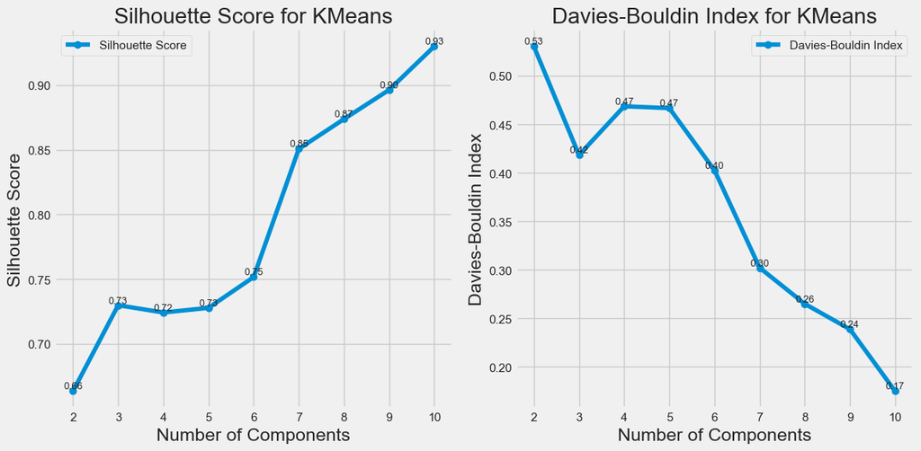

```
2026-01-13 21:40:21,926 - INFO - Plots for KMeans displayed.
2026-01-13 21:40:21,927 - INFO - Processing Ward...
2026-01-13 21:40:21,928 - INFO - Plotting results for Ward...
```

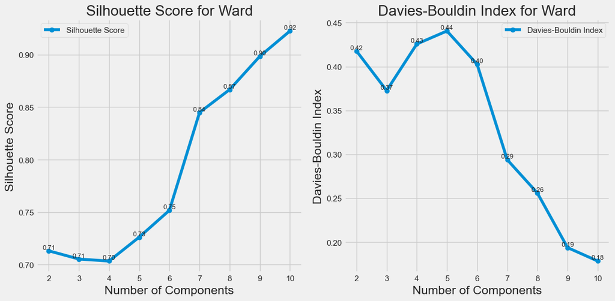

```
2026-01-13 21:40:22,179 - INFO - Plots for Ward displayed.
2026-01-13 21:40:22,179 - INFO - Processing GMM...
2026-01-13 21:40:22,179 - INFO - Plotting results for GMM...
```

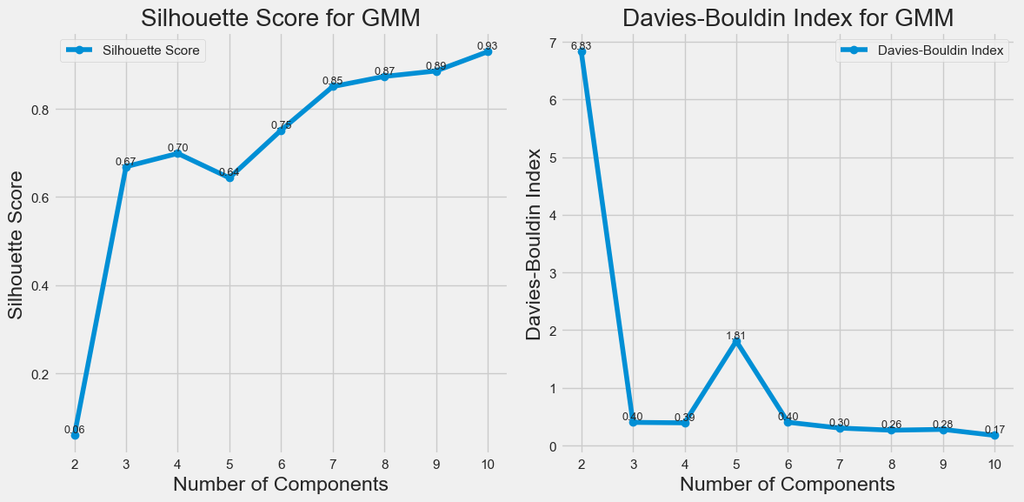

```
2026-01-13 21:40:22,425 - INFO - Plots for GMM displayed.
2026-01-13 21:40:22,426 - INFO - Processing DBSCAN...
2026-01-13 21:40:22,426 - INFO - Plotting results for DBSCAN...
```

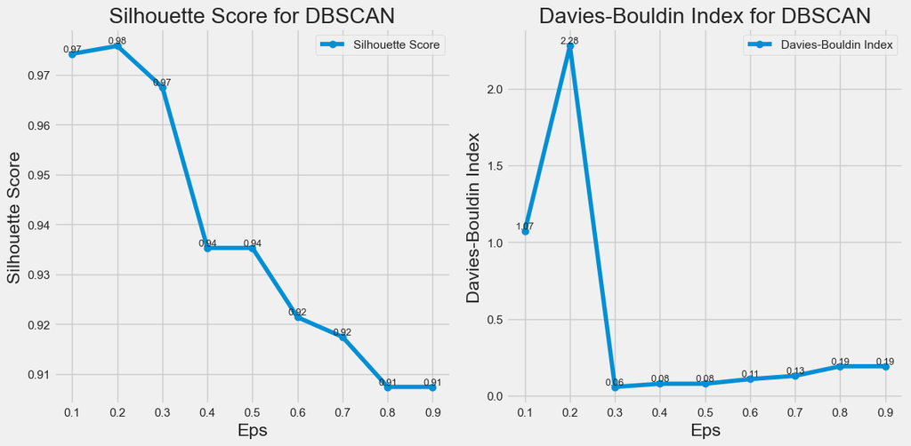

```
2026-01-13 21:40:22,680 - INFO - Plots for DBSCAN displayed.
```

```python
# Plot results for each algorithm that requires n_components
algorithms = ['KMeans', 'Ward', 'GMM']
for algorithm in algorithms:
    logger.info(f"Processing {algorithm}...")
    silhouette_scores = []
    davies_bouldin_scores = []

    for n_components in n_components_range:
        key = f'{algorithm}_{n_components}'
        silhouette_scores.append(results[key]['Silhouette Score'])
        davies_bouldin_scores.append(results[key]['Davies-Bouldin Index'])

    plot_algorithm_scores(algorithm, n_components_range, silhouette_scores, davies_bouldin_scores, 'Number of Components')

# Plot results for DBSCAN
logger.info("Processing DBSCAN...")
plot_algorithm_scores('DBSCAN', eps_range, silhouette_scores_dbscan, davies_bouldin_scores_dbscan, 'Eps')
```

#### **Cluster Visulization**

```
2026-01-13 21:40:22,700 - INFO - Visualizing clusters for Kmeans...
```

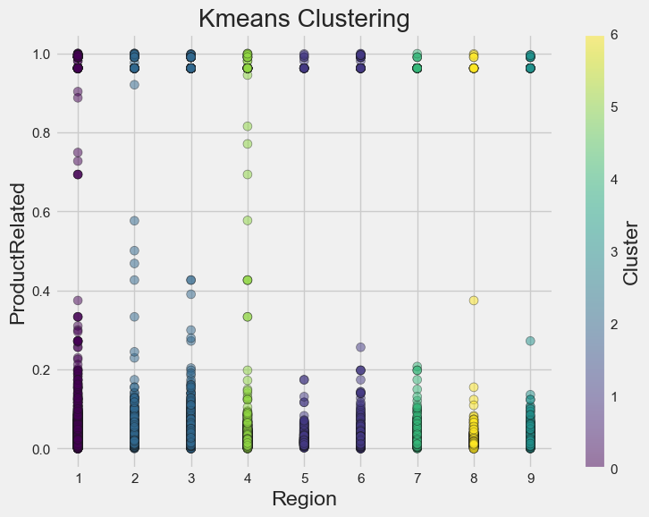

```
2026-01-13 21:40:23,007 - INFO - Cluster visualization for Kmeans displayed.

2026-01-13 21:40:23,008 - INFO - ------------------------------------------------------
2026-01-13 21:40:25,652 - INFO - Visualizing clusters for Ward...
```

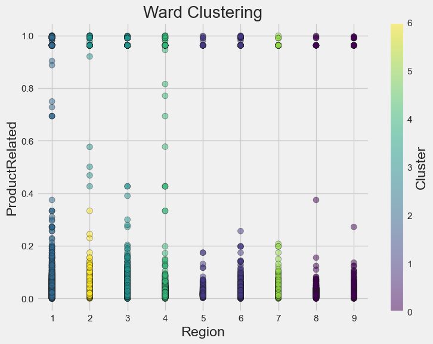

```
2026-01-13 21:40:25,942 - INFO - Cluster visualization for Ward displayed.

2026-01-13 21:40:25,943 - INFO - ------------------------------------------------------
2026-01-13 21:40:26,002 - INFO - Visualizing clusters for GMM...
```

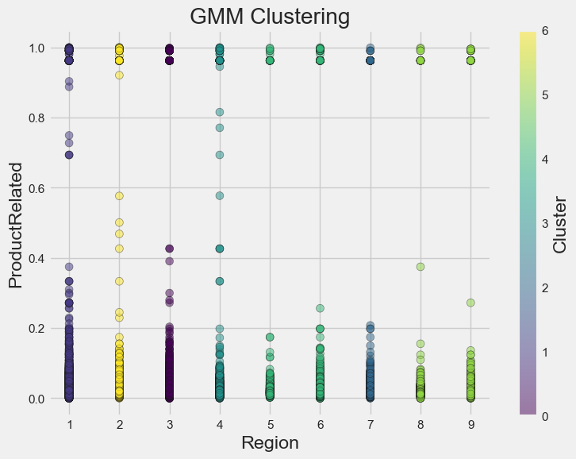

```
2026-01-13 21:40:26,289 - INFO - Cluster visualization for GMM displayed.

2026-01-13 21:40:26,290 - INFO - ------------------------------------------------------
2026-01-13 21:40:26,300 - INFO - Visualizing clusters for DBSCAN...
```

[figure not shown]

```
2026-01-13 21:40:26,610 - INFO - Cluster visualization for DBSCAN displayed.

2026-01-13 21:40:26,611 - INFO - ------------------------------------------------------
2026-01-13 21:40:26,611 - INFO - ------------------------------------------------------
```

```python
# Visualize Kmeans clusters
kmeans= KMeans(n_clusters=7)
labels_kmeans = kmeans.fit_predict(X_FSSEM_cls)
visualize_clusters(X_FSSEM_cls, labels_kmeans, 'Kmeans')

# Visualize Ward clusters
ward = AgglomerativeClustering(n_clusters=7)
labels_ward = ward.fit_predict(X_FSSEM_cls)
visualize_clusters(X_FSSEM_cls, labels_ward, 'Ward')

# Visualize GMM clusters
gmm = GaussianMixture(n_components=7, covariance_type='full', random_state=42)
labels_gmm = gmm.fit_predict(X_FSSEM_cls)
visualize_clusters(X_FSSEM_cls, labels_gmm, 'GMM')

# Visualize DBSCAN clusters
dbscan = DBSCAN(eps=0.3, min_samples=10)
labels_dbscan = kmeans.fit_predict(X_FSSEM_cls)
visualize_clusters(X_FSSEM_cls, labels_dbscan, 'DBSCAN')
```

### **Subset Feature from Similarity Search**

#### **Cluster Evaluation**

```python
# Evaluate clustering algorithms that require n_components
logger.info(f"Evaluating clustering algorithms for n_components_range = {list(n_components_range)}...")
results = evaluate_clustering(X_FS_cls, n_components_range)

# Evaluate DBSCAN for the range of eps values
silhouette_scores_dbscan, davies_bouldin_scores_dbscan = evaluate_dbscan(X_FS_cls, eps_range, min_samples)
```

[output not shown]

```
2026-01-13 21:41:44,781 - INFO - Processing KMeans...
2026-01-13 21:41:44,782 - INFO - Plotting results for KMeans...
```

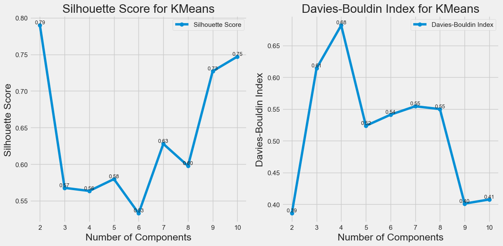

```
2026-01-13 21:41:45,055 - INFO - Plots for KMeans displayed.
2026-01-13 21:41:45,056 - INFO - Processing Ward...
2026-01-13 21:41:45,057 - INFO - Plotting results for Ward...
```

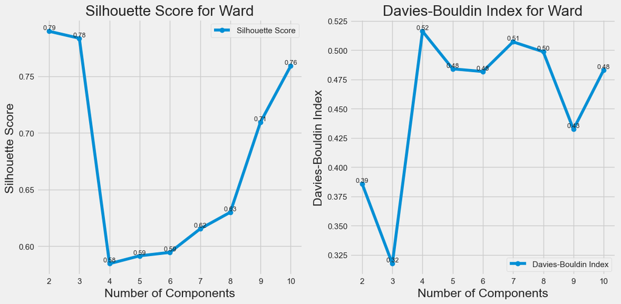

```
2026-01-13 21:41:45,567 - INFO - Plots for Ward displayed.
2026-01-13 21:41:45,568 - INFO - Processing GMM...
2026-01-13 21:41:45,568 - INFO - Plotting results for GMM...
```

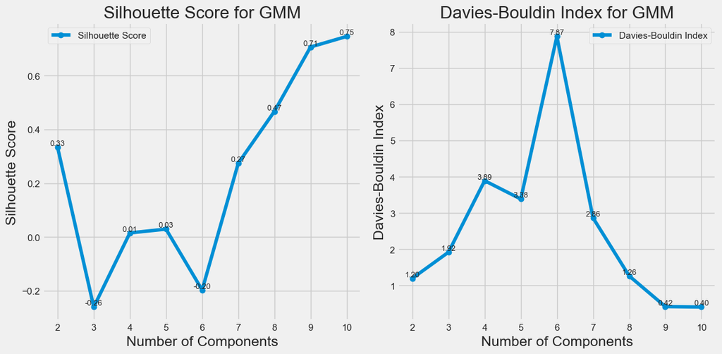

```
2026-01-13 21:41:45,832 - INFO - Plots for GMM displayed.
2026-01-13 21:41:45,832 - INFO - Processing DBSCAN...
2026-01-13 21:41:45,833 - INFO - Plotting results for DBSCAN...
```

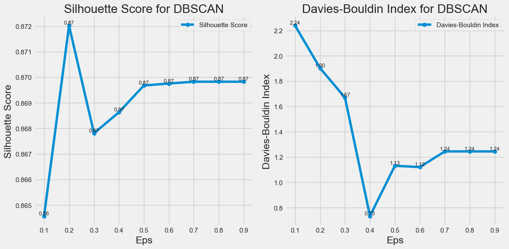

```
2026-01-13 21:41:46,108 - INFO - Plots for DBSCAN displayed.
```

```python
# Plot results for each algorithm that requires n_components
algorithms = ['KMeans', 'Ward', 'GMM']
for algorithm in algorithms:
    logger.info(f"Processing {algorithm}...")
    silhouette_scores = []
    davies_bouldin_scores = []

    for n_components in n_components_range:
        key = f'{algorithm}_{n_components}'
        silhouette_scores.append(results[key]['Silhouette Score'])
        davies_bouldin_scores.append(results[key]['Davies-Bouldin Index'])

    plot_algorithm_scores(algorithm, n_components_range, silhouette_scores, davies_bouldin_scores, 'Number of Components')

# Plot results for DBSCAN
logger.info("Processing DBSCAN...")
plot_algorithm_scores('DBSCAN', eps_range, silhouette_scores_dbscan, davies_bouldin_scores_dbscan, 'Eps')
```

#### **Cluster Visualization**

```
(<Figure size 640x480 with 2 Axes>,
 <Axes3D: xlabel='Revenue', ylabel='ProductRelated_Duration', zlabel='TrafficType'>)
```

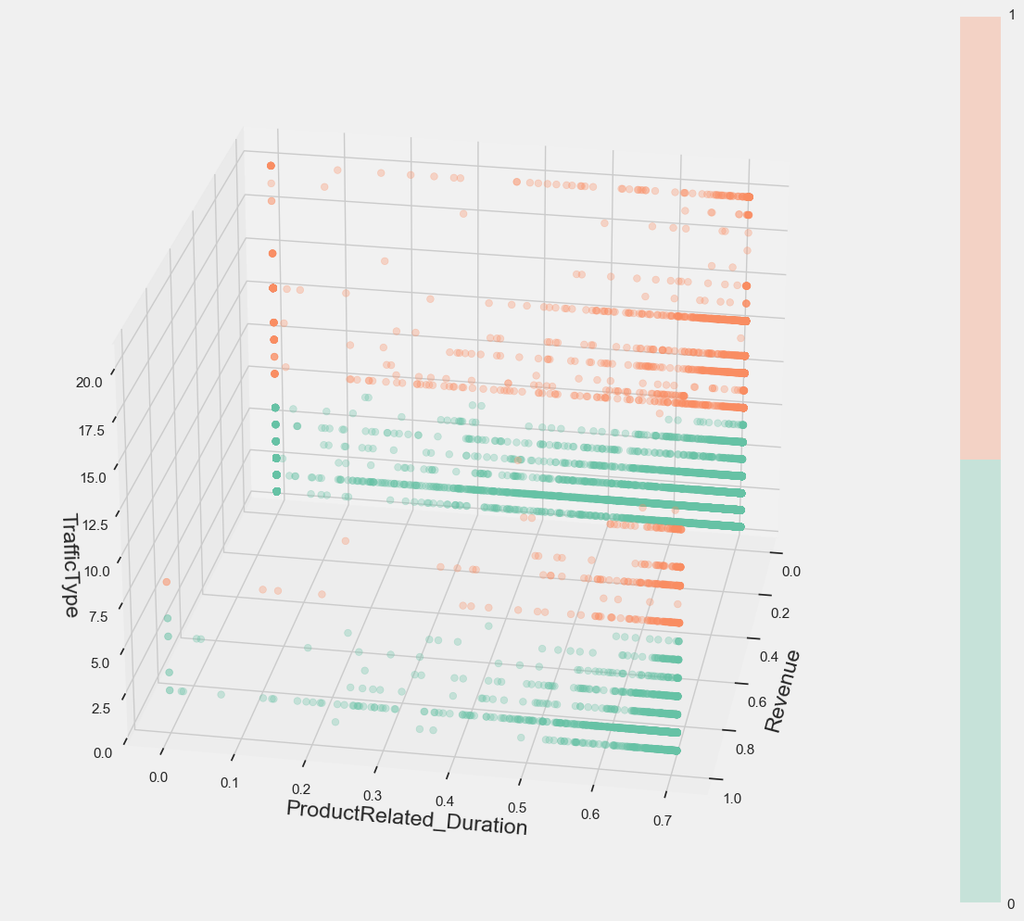

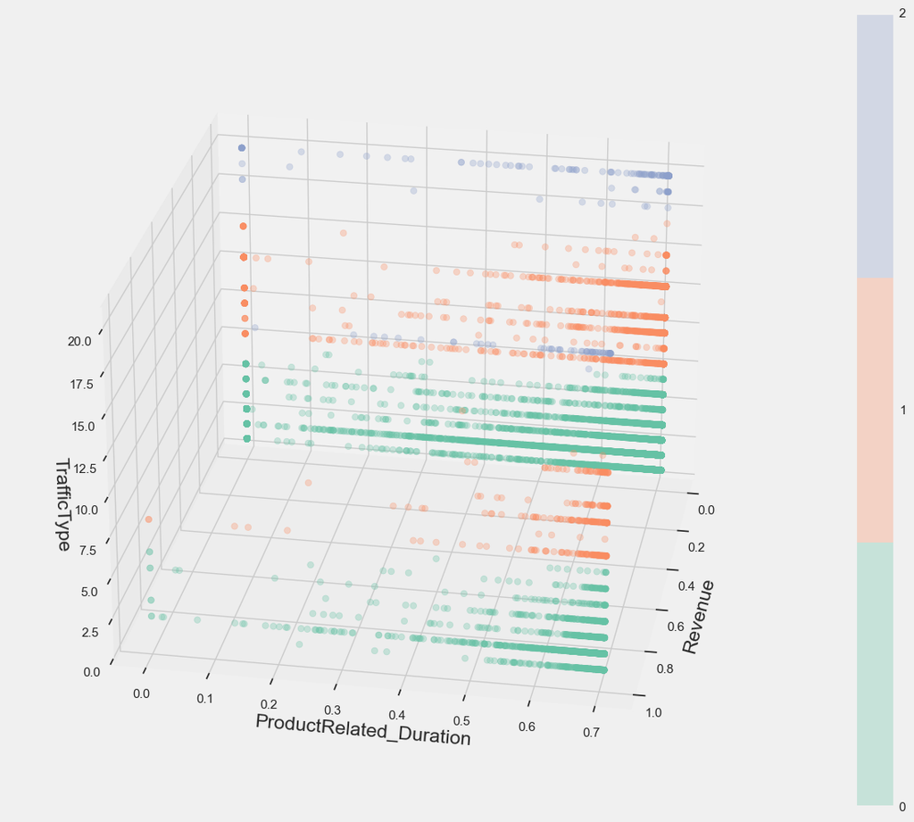

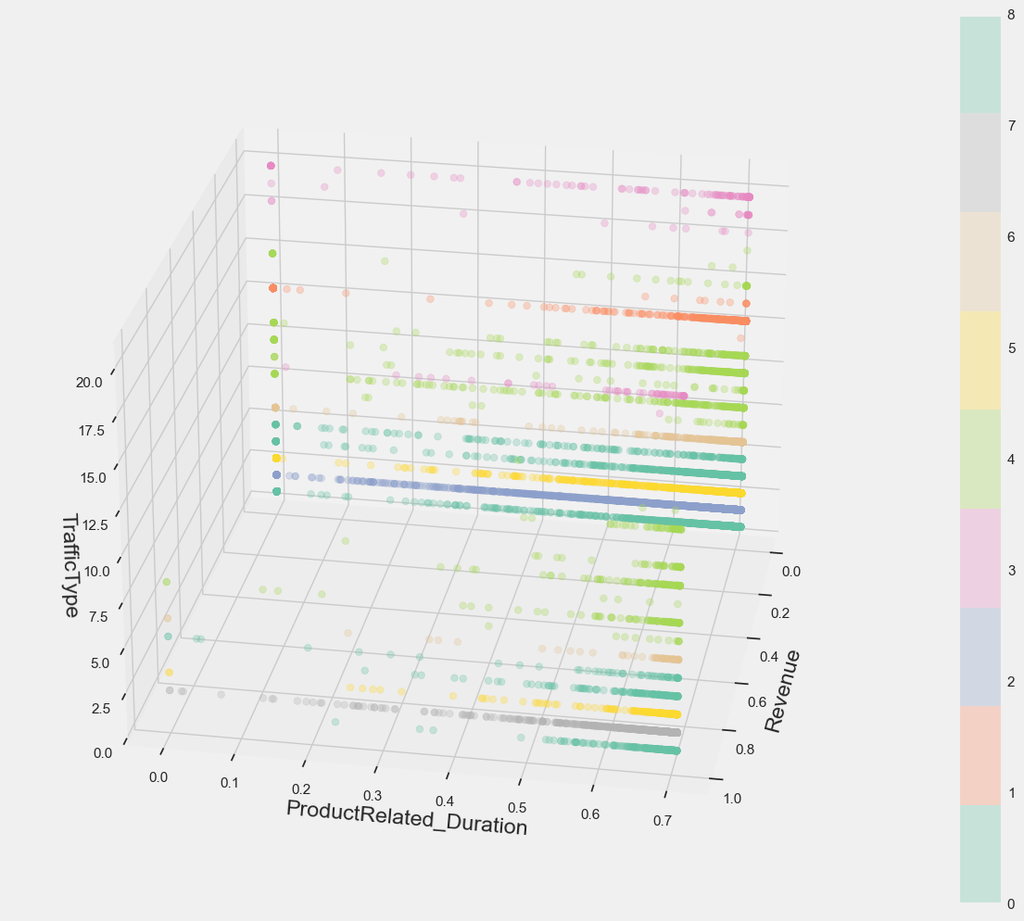

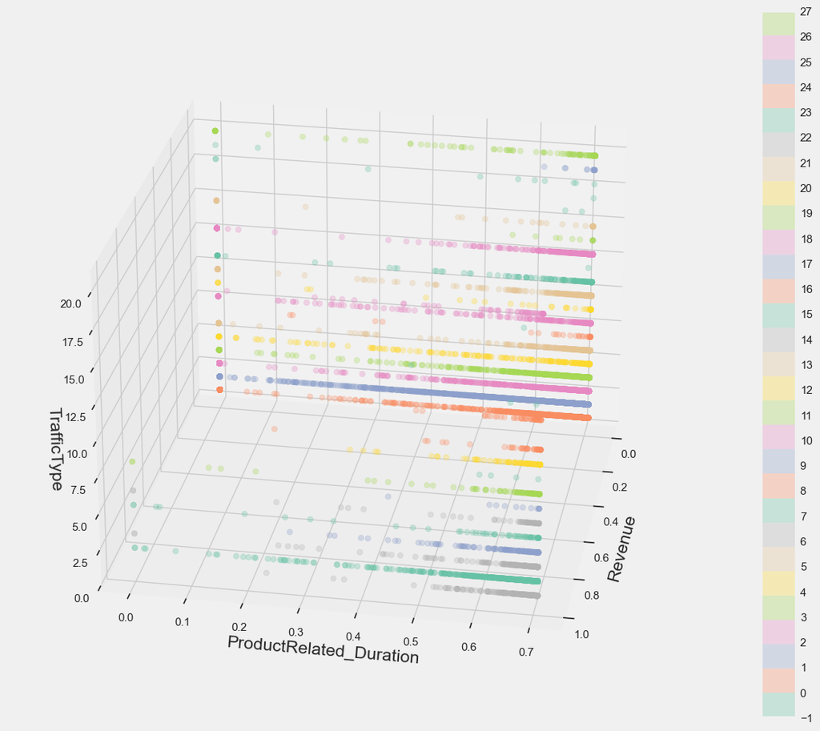

```python
kmeans= KMeans(n_clusters=2)
labels_kmeans = kmeans.fit_predict(X_FS_cls)
show_scatter_3d(df_clustering, X_FS_cls.columns[0], X_FS_cls.columns[1], X_FS_cls.columns[2], predicted=labels_kmeans, show_colorbar=True)

# Visualize Ward clusters
ward = AgglomerativeClustering(n_clusters=3)
labels_ward = ward.fit_predict(X_FS_cls)
show_scatter_3d(df_clustering, X_FS_cls.columns[0], X_FS_cls.columns[1], X_FS_cls.columns[2], predicted=labels_ward, show_colorbar=True)

# Visualize GMM clusters
gmm = GaussianMixture(n_components=9, covariance_type='full', random_state=42)
labels_gmm = gmm.fit_predict(X_FS_cls)
show_scatter_3d(df_clustering, X_FS_cls.columns[0], X_FS_cls.columns[1], X_FS_cls.columns[2], predicted=labels_gmm, show_colorbar=True)

# Visualize DBSCAN clusters
dbscan = DBSCAN(eps=0.4, min_samples=10)
labels_dbscan = dbscan.fit_predict(X_FS_cls)
show_scatter_3d(df_clustering, X_FS_cls.columns[0], X_FS_cls.columns[1], X_FS_cls.columns[2], predicted=labels_dbscan, show_colorbar=True)
```

## **Classification Task**

In the classification task, modeling is performed at two levels: the **data level** and the **algorithmic level**. At the **data level**, techniques are applied to address class imbalance, including **Undersampling** (reducing the majority class), **Oversampling** (increasing the minority class, e.g., using SMOTE), and **HybridSampling** (a combination of both). These methods aim to balance the dataset and improve model performance on minority classes. At the **algorithmic level**, three approaches are implemented: the **threshold method**, which adjusts the decision threshold to optimize classification outcomes; **cost-sensitive learning**, where class weights are adjusted to penalize misclassifications of the minority class more heavily; and a combination of **cost-sensitive learning + threshold method** for enhanced performance. The threshold method is also applied to the three data-level sampling techniques (Undersampling, Oversampling, HybridSampling) to evaluate their combined impact. For each method and its combinations, base models such as **RandomForest**, **GradientBoosting**, **HistGradientBoosting**, **ExtraTrees**, and **DecisionTree** are built, followed by **hyperparameter tuning** to optimize model performance. Additionally, for each model, the **ROC-AUC score** is plotted to evaluate the trade-off between true positive rate and false positive rate across different thresholds, providing a comprehensive measure of classification performance. This approach ensures robust evaluation and improvement of classification results across diverse scenarios.

### **Base Level**

#### **Base model**

```
Training and evaluating base RandomForest...

Results for  RandomForest:
	Optimal Threshold: 0.5000
	Classification Report:
               precision    recall  f1-score   support

           0       0.93      0.97      0.95      2072
           1       0.78      0.59      0.68       369

    accuracy                           0.91      2441
   macro avg       0.86      0.78      0.81      2441
weighted avg       0.91      0.91      0.91      2441

	ROC-AUC Score: 0.9262
	F1 Score: 0.6759
	G-mean: 0.7592
	Confusion Matrix:
 [[2012   60]
 [ 150  219]]
```

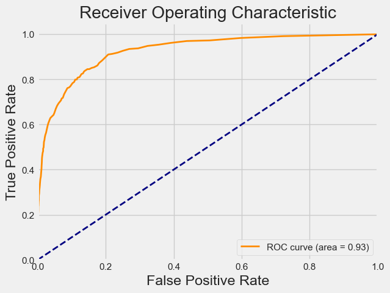

```
Training and evaluating base GradientBoosting...

Results for  GradientBoosting:
	Optimal Threshold: 0.5000
	Classification Report:
               precision    recall  f1-score   support

           0       0.93      0.96      0.95      2072
           1       0.74      0.62      0.68       369

    accuracy                           0.91      2441
   macro avg       0.84      0.79      0.81      2441
weighted avg       0.91      0.91      0.91      2441

	ROC-AUC Score: 0.9353
	F1 Score: 0.6755
	G-mean: 0.7724
	Confusion Matrix:
 [[1992   80]
 [ 140  229]]
```

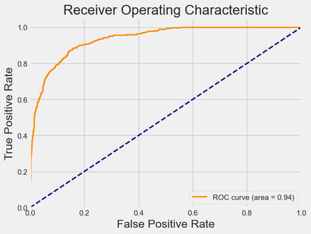

```
Training and evaluating base HistGradientBoosting...

Results for  HistGradientBoosting:
	Optimal Threshold: 0.5000
	Classification Report:
               precision    recall  f1-score   support

           0       0.93      0.96      0.95      2072
           1       0.74      0.62      0.68       369

    accuracy                           0.91      2441
   macro avg       0.84      0.79      0.81      2441
weighted avg       0.91      0.91      0.91      2441

	ROC-AUC Score: 0.9378
	F1 Score: 0.6765
	G-mean: 0.7739
	Confusion Matrix:
 [[1991   81]
 [ 139  230]]
```

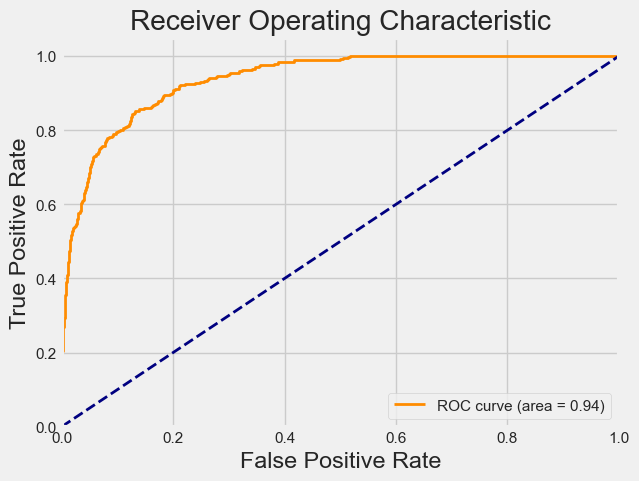

```
Training and evaluating base ExtraTrees...

Results for  ExtraTrees:
	Optimal Threshold: 0.5000
	Classification Report:
               precision    recall  f1-score   support

           0       0.92      0.98      0.95      2072
           1       0.79      0.51      0.62       369

    accuracy                           0.91      2441
   macro avg       0.86      0.74      0.78      2441
weighted avg       0.90      0.91      0.90      2441

	ROC-AUC Score: 0.9195
	F1 Score: 0.6227
	G-mean: 0.7072
	Confusion Matrix:
 [[2023   49]
 [ 180  189]]
```

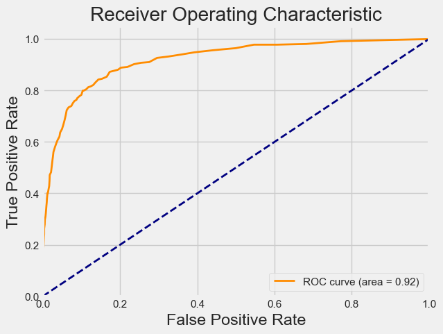

```
Training and evaluating base DecisionTree...

Results for  DecisionTree:
	Optimal Threshold: 0.5000
	Classification Report:
               precision    recall  f1-score   support

           0       0.93      0.91      0.92      2072
           1       0.55      0.59      0.57       369

    accuracy                           0.87      2441
   macro avg       0.74      0.75      0.74      2441
weighted avg       0.87      0.87      0.87      2441

	ROC-AUC Score: 0.7513
	F1 Score: 0.5688
	G-mean: 0.7334
	Confusion Matrix:
 [[1895  177]
 [ 152  217]]
```

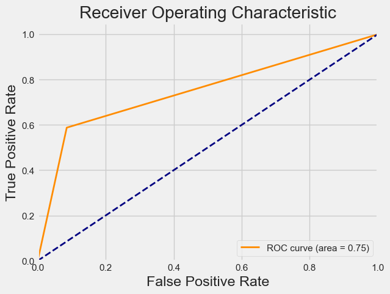

```python
base_result = {}
for model_name, config in models.items():
    print(f"Training and evaluating base {model_name}...")
    results = train_evaluate_model(
        model=config["base_model"],
        model_name = model_name,
        X_train=X_train_clf,
        y_train=y_train_clf,
        X_test=X_test_clf,
        y_test=y_test_clf,
    )
    base_result[model_name] = results
```

#### **Tunned model**

```
Training and evaluating base RandomForest with Hyperparameter tuning...
Fitting 5 folds for each of 20 candidates, totalling 100 fits

Results for  RandomForest:
	Best Hyperparameters: {'bootstrap': False, 'class_weight': 'balanced', 'max_depth': 30, 'max_features': 'log2', 'min_samples_leaf': 5, 'min_samples_split': 8, 'n_estimators': 336}
	Optimal Threshold: 0.5000
	Classification Report:
               precision    recall  f1-score   support

           0       0.96      0.91      0.93      2072
           1       0.60      0.79      0.68       369

    accuracy                           0.89      2441
   macro avg       0.78      0.85      0.81      2441
weighted avg       0.91      0.89      0.89      2441

	ROC-AUC Score: 0.9304
	F1 Score: 0.6815
	G-mean: 0.8454
	Confusion Matrix:
 [[1878  194]
 [  78  291]]
```

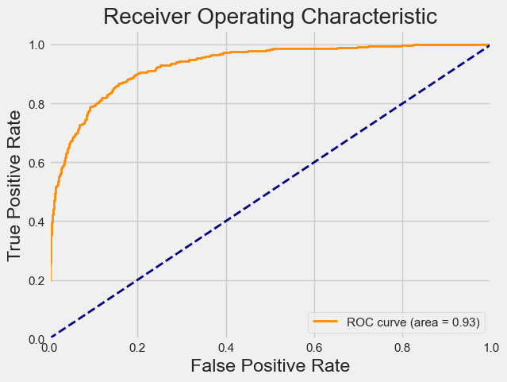

```
Training and evaluating base GradientBoosting with Hyperparameter tuning...
Fitting 5 folds for each of 20 candidates, totalling 100 fits

Results for  GradientBoosting:
	Best Hyperparameters: {'learning_rate': np.float64(0.023999698964084628), 'loss': 'exponential', 'max_depth': 9, 'max_features': 'log2', 'min_samples_leaf': 15, 'min_samples_split': 13, 'n_estimators': 154, 'subsample': np.float64(0.9916154429033941)}
	Optimal Threshold: 0.5000
	Classification Report:
               precision    recall  f1-score   support

           0       0.93      0.97      0.95      2072
           1       0.77      0.60      0.67       369

    accuracy                           0.91      2441
   macro avg       0.85      0.78      0.81      2441
weighted avg       0.91      0.91      0.91      2441

	ROC-AUC Score: 0.9370
	F1 Score: 0.6738
	G-mean: 0.7601
	Confusion Matrix:
 [[2008   64]
 [ 149  220]]
```

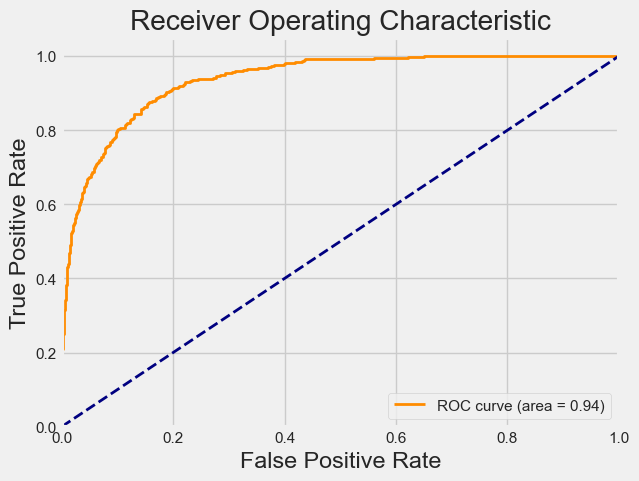

```
Training and evaluating base HistGradientBoosting with Hyperparameter tuning...
Fitting 5 folds for each of 20 candidates, totalling 100 fits

Results for  HistGradientBoosting:
	Best Hyperparameters: {'class_weight': 'balanced', 'early_stopping': False, 'l2_regularization': np.float64(0.03142918568673425), 'learning_rate': np.float64(0.20092312337913412), 'max_bins': 101, 'max_depth': 7, 'max_iter': 195, 'max_leaf_nodes': 13, 'min_samples_leaf': 5}
	Optimal Threshold: 0.5000
	Classification Report:
               precision    recall  f1-score   support

           0       0.96      0.89      0.93      2072
           1       0.57      0.79      0.66       369

    accuracy                           0.88      2441
   macro avg       0.77      0.84      0.80      2441
weighted avg       0.90      0.88      0.89      2441

	ROC-AUC Score: 0.9303
	F1 Score: 0.6644
	G-mean: 0.8415
	Confusion Matrix:
 [[1854  218]
 [  77  292]]
```

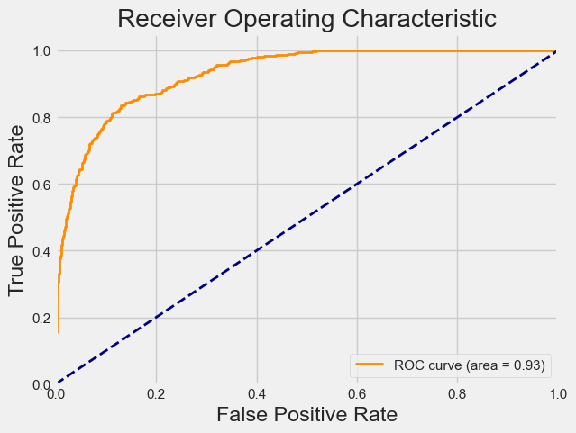

```
Training and evaluating base ExtraTrees with Hyperparameter tuning...
Fitting 5 folds for each of 20 candidates, totalling 100 fits

Results for  ExtraTrees:
	Best Hyperparameters: {'bootstrap': False, 'class_weight': 'balanced_subsample', 'max_depth': None, 'max_features': None, 'min_samples_leaf': 5, 'min_samples_split': 4, 'n_estimators': 271}
	Optimal Threshold: 0.5000
	Classification Report:
               precision    recall  f1-score   support

           0       0.96      0.89      0.93      2072
           1       0.57      0.81      0.67       369

    accuracy                           0.88      2441
   macro avg       0.76      0.85      0.80      2441
weighted avg       0.90      0.88      0.89      2441

	ROC-AUC Score: 0.9335
	F1 Score: 0.6659
	G-mean: 0.8478
	Confusion Matrix:
 [[1844  228]
 [  71  298]]
```

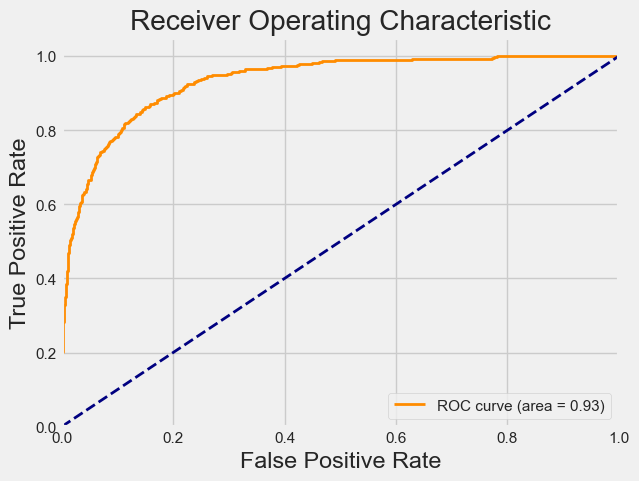

```
Training and evaluating base DecisionTree with Hyperparameter tuning...
Fitting 5 folds for each of 20 candidates, totalling 100 fits

Results for  DecisionTree:
	Best Hyperparameters: {'class_weight': 'balanced', 'criterion': 'gini', 'max_depth': 10, 'max_features': None, 'min_samples_leaf': 11, 'min_samples_split': 12, 'splitter': 'random'}
	Optimal Threshold: 0.5000
	Classification Report:
               precision    recall  f1-score   support

           0       0.97      0.88      0.92      2072
           1       0.54      0.83      0.66       369

    accuracy                           0.87      2441
   macro avg       0.76      0.86      0.79      2441
weighted avg       0.90      0.87      0.88      2441

	ROC-AUC Score: 0.8974
	F1 Score: 0.6588
	G-mean: 0.8548
	Confusion Matrix:
 [[1814  258]
 [  61  308]]
```

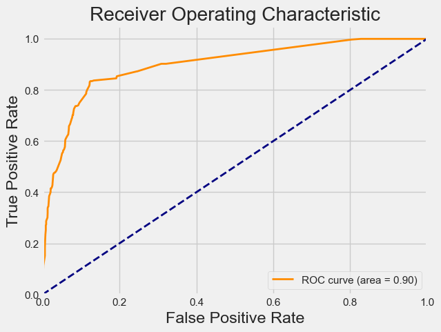

```python
tunned_result = {}
for model_name, config in models.items():
    print(f"Training and evaluating base {model_name} with Hyperparameter tuning...")
    results = train_evaluate_model(
        model=config["base_model"],
        model_name=model_name,
        X_train=X_train_clf,
        y_train=y_train_clf,
        X_test=X_test_clf,
        y_test=y_test_clf,
        params=config["params"],
        search=True
    )
    tunned_result[model_name] = results
```

### **Data Level**

#### **Under sampling**

##### *Base model*

```
Training and evaluating base RandomForest with Undersampling...
```

```
Results for  RandomForest:
	Optimal Threshold: 0.5000
	Classification Report:
               precision    recall  f1-score   support

           0       0.97      0.61      0.75      2072
           1       0.29      0.90      0.44       369

    accuracy                           0.66      2441
   macro avg       0.63      0.76      0.60      2441
weighted avg       0.87      0.66      0.71      2441

	ROC-AUC Score: 0.8235
	F1 Score: 0.4430
	G-mean: 0.7438
	Confusion Matrix:
 [[1274  798]
 [  37  332]]
```

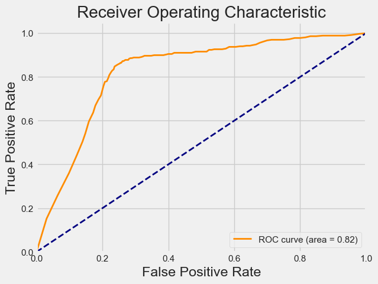

```
Training and evaluating base GradientBoosting with Undersampling...

Results for  GradientBoosting:
	Optimal Threshold: 0.5000
	Classification Report:
               precision    recall  f1-score   support

           0       0.97      0.60      0.74      2072
           1       0.29      0.90      0.43       369

    accuracy                           0.65      2441
   macro avg       0.63      0.75      0.59      2441
weighted avg       0.87      0.65      0.70      2441

	ROC-AUC Score: 0.8271
	F1 Score: 0.4335
	G-mean: 0.7342
	Confusion Matrix:
 [[1245  827]
 [  38  331]]
```

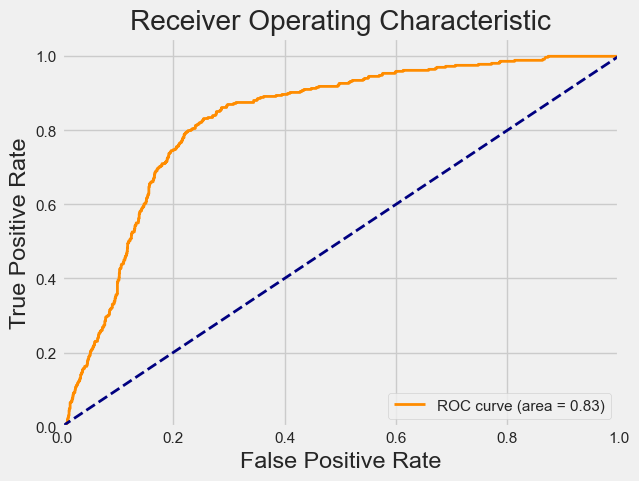

```
Training and evaluating base HistGradientBoosting with Undersampling...

Results for  HistGradientBoosting:
	Optimal Threshold: 0.5000
	Classification Report:
               precision    recall  f1-score   support

           0       0.97      0.60      0.74      2072
           1       0.29      0.91      0.44       369

    accuracy                           0.65      2441
   macro avg       0.63      0.75      0.59      2441
weighted avg       0.87      0.65      0.70      2441

	ROC-AUC Score: 0.8326
	F1 Score: 0.4372
	G-mean: 0.7381
	Confusion Matrix:
 [[1247  825]
 [  35  334]]
```

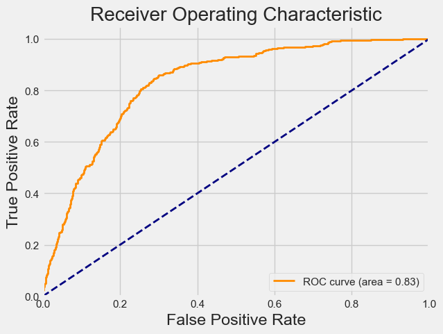

```
Training and evaluating base ExtraTrees with Undersampling...

Results for  ExtraTrees:
	Optimal Threshold: 0.5000
	Classification Report:
               precision    recall  f1-score   support

           0       0.97      0.54      0.69      2072
           1       0.26      0.91      0.40       369

    accuracy                           0.59      2441
   macro avg       0.61      0.72      0.55      2441
weighted avg       0.86      0.59      0.65      2441

	ROC-AUC Score: 0.8015
	F1 Score: 0.4019
	G-mean: 0.6971
	Confusion Matrix:
 [[1109  963]
 [  34  335]]
```

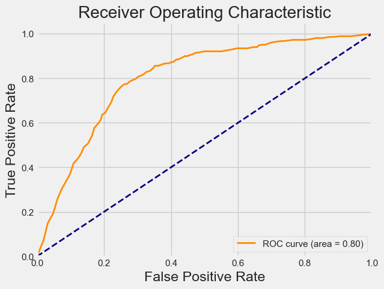

```
Training and evaluating base DecisionTree with Undersampling...

Results for  DecisionTree:
	Optimal Threshold: 0.5000
	Classification Report:
               precision    recall  f1-score   support

           0       0.96      0.51      0.67      2072
           1       0.25      0.89      0.38       369

    accuracy                           0.57      2441
   macro avg       0.60      0.70      0.53      2441
weighted avg       0.86      0.57      0.63      2441

	ROC-AUC Score: 0.7016
	F1 Score: 0.3848
	G-mean: 0.6754
	Confusion Matrix:
 [[1060 1012]
 [  40  329]]
```

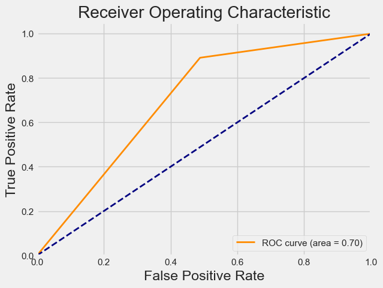

```python
undersampling_base_result = {}
for model_name, config in models.items():
    print(f"Training and evaluating base {model_name} with Undersampling...")
    results = train_evaluate_model(
        model=config["base_model"],
        model_name = model_name,
        X_train=X_train_clf,
        y_train=y_train_clf,
        X_test=X_test_clf,
        y_test=y_test_clf,
        pipeline=ImbPipeline(steps=[
            ('smote', NearMiss()),
            ('model', config["base_model"])
        ])
    )
    undersampling_base_result[model_name] = results
```

##### *Tunned model*

```
Training and evaluating base RandomForest with Undersampling and Hyperparameter tuning...
Fitting 5 folds for each of 20 candidates, totalling 100 fits

Results for  RandomForest:
	Best Hyperparameters: {'model__bootstrap': True, 'model__class_weight': None, 'model__max_depth': 10, 'model__max_features': 'sqrt', 'model__min_samples_leaf': 14, 'model__min_samples_split': 19, 'model__n_estimators': 364}
	Optimal Threshold: 0.5000
	Classification Report:
               precision    recall  f1-score   support

           0       0.97      0.70      0.81      2072
           1       0.34      0.89      0.50       369

    accuracy                           0.73      2441
   macro avg       0.66      0.79      0.65      2441
weighted avg       0.88      0.73      0.77      2441

	ROC-AUC Score: 0.8431
	F1 Score: 0.4958
	G-mean: 0.7872
	Confusion Matrix:
 [[1449  623]
 [  42  327]]
```

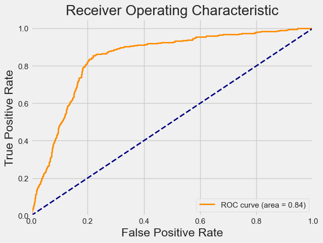

```
Training and evaluating base GradientBoosting with Undersampling and Hyperparameter tuning...
Fitting 5 folds for each of 20 candidates, totalling 100 fits

Results for  GradientBoosting:
	Best Hyperparameters: {'model__learning_rate': np.float64(0.06597101766581075), 'model__loss': 'exponential', 'model__max_depth': 8, 'model__max_features': None, 'model__min_samples_leaf': 7, 'model__min_samples_split': 2, 'model__n_estimators': 484, 'model__subsample': np.float64(0.613967581270970…
	Optimal Threshold: 0.5000
	Classification Report:
               precision    recall  f1-score   support

           0       0.97      0.66      0.79      2072
           1       0.32      0.90      0.48       369

    accuracy                           0.70      2441
   macro avg       0.65      0.78      0.63      2441
weighted avg       0.88      0.70      0.74      2441

	ROC-AUC Score: 0.8613
	F1 Score: 0.4761
	G-mean: 0.7739
	Confusion Matrix:
 [[1375  697]
 [  36  333]]
```

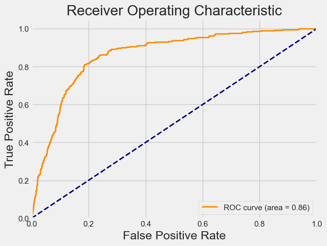

```
Training and evaluating base HistGradientBoosting with Undersampling and Hyperparameter tuning...
Fitting 5 folds for each of 20 candidates, totalling 100 fits

Results for  HistGradientBoosting:
	Best Hyperparameters: {'model__class_weight': None, 'model__early_stopping': 'auto', 'model__l2_regularization': np.float64(0.1834347898661638), 'model__learning_rate': np.float64(0.24390730008183079), 'model__max_bins': 70, 'model__max_depth': 9, 'model__max_iter': 221, 'model__max_leaf_nodes': 92…
	Optimal Threshold: 0.5000
	Classification Report:
               precision    recall  f1-score   support

           0       0.97      0.62      0.76      2072
           1       0.30      0.91      0.45       369

    accuracy                           0.66      2441
   macro avg       0.64      0.77      0.60      2441
weighted avg       0.87      0.66      0.71      2441

	ROC-AUC Score: 0.8460
	F1 Score: 0.4510
	G-mean: 0.7521
	Confusion Matrix:
 [[1287  785]
 [  33  336]]
```

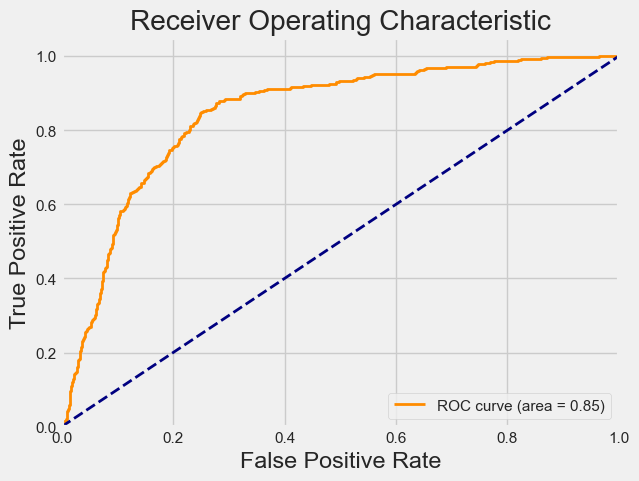

```
Training and evaluating base ExtraTrees with Undersampling and Hyperparameter tuning...
Fitting 5 folds for each of 20 candidates, totalling 100 fits

Results for  ExtraTrees:
	Best Hyperparameters: {'model__bootstrap': True, 'model__class_weight': 'balanced_subsample', 'model__max_depth': 30, 'model__max_features': None, 'model__min_samples_leaf': 15, 'model__min_samples_split': 13, 'model__n_estimators': 154}
	Optimal Threshold: 0.5000
	Classification Report:
               precision    recall  f1-score   support

           0       0.97      0.69      0.80      2072
           1       0.34      0.89      0.49       369

    accuracy                           0.72      2441
   macro avg       0.65      0.79      0.65      2441
weighted avg       0.88      0.72      0.76      2441

	ROC-AUC Score: 0.8545
	F1 Score: 0.4870
	G-mean: 0.7810
	Confusion Matrix:
 [[1422  650]
 [  41  328]]
```

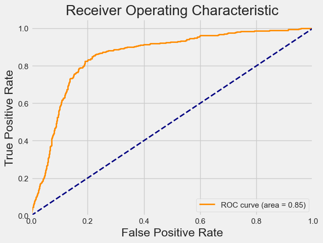

```
Training and evaluating base DecisionTree with Undersampling and Hyperparameter tuning...
Fitting 5 folds for each of 20 candidates, totalling 100 fits

Results for  DecisionTree:
	Best Hyperparameters: {'model__class_weight': 'balanced', 'model__criterion': 'entropy', 'model__max_depth': 50, 'model__max_features': None, 'model__min_samples_leaf': 12, 'model__min_samples_split': 9, 'model__splitter': 'random'}
	Optimal Threshold: 0.5000
	Classification Report:
               precision    recall  f1-score   support

           0       0.96      0.76      0.85      2072
           1       0.38      0.84      0.52       369

    accuracy                           0.77      2441
   macro avg       0.67      0.80      0.69      2441
weighted avg       0.88      0.77      0.80      2441

	ROC-AUC Score: 0.8410
	F1 Score: 0.5241
	G-mean: 0.7973
	Confusion Matrix:
 [[1568  504]
 [  59  310]]
```

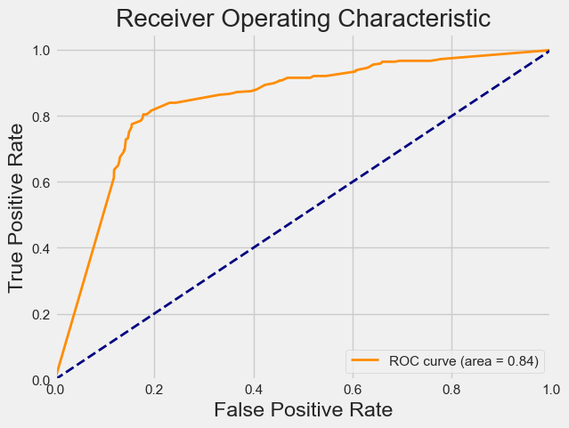

```python
undersampling_tunned_result = {}
for model_name, config in models.items():
    print(f"Training and evaluating base {model_name} with Undersampling and Hyperparameter tuning...")
    results = train_evaluate_model(
        model=config["base_model"],
        model_name=model_name,
        X_train=X_train_clf,
        y_train=y_train_clf,
        X_test=X_test_clf,
        y_test=y_test_clf,
        params={"model__" + key: value for key, value in config["params"].items()},
        pipeline=ImbPipeline(steps=[
            ('NearMiss', NearMiss()),
            ('model', config["base_model"])
        ]),
        search=True
    )
    undersampling_tunned_result[model_name] = results
```

#### **Over sampling**

##### *Base model*

```
Training and evaluating base RandomForest with oversampling...

Results for  RandomForest:
	Optimal Threshold: 0.5000
	Classification Report:
               precision    recall  f1-score   support

           0       0.95      0.92      0.94      2072
           1       0.62      0.74      0.67       369

    accuracy                           0.89      2441
   macro avg       0.79      0.83      0.81      2441
weighted avg       0.90      0.89      0.90      2441

	ROC-AUC Score: 0.9278
	F1 Score: 0.6749
	G-mean: 0.8258
	Confusion Matrix:
 [[1903  169]
 [  95  274]]
```

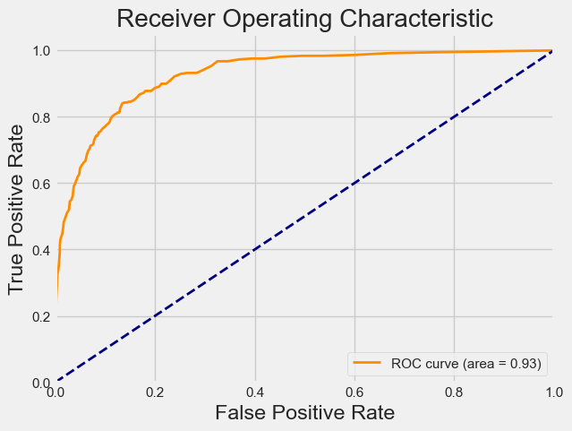

```
Training and evaluating base GradientBoosting with oversampling...

Results for  GradientBoosting:
	Optimal Threshold: 0.5000
	Classification Report:
               precision    recall  f1-score   support

           0       0.95      0.91      0.93      2072
           1       0.60      0.76      0.67       369

    accuracy                           0.89      2441
   macro avg       0.78      0.83      0.80      2441
weighted avg       0.90      0.89      0.89      2441

	ROC-AUC Score: 0.9304
	F1 Score: 0.6667
	G-mean: 0.8289
	Confusion Matrix:
 [[1883  189]
 [  90  279]]
```

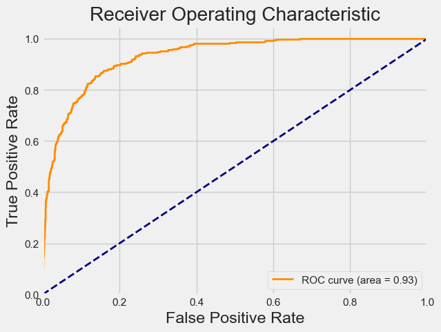

```
Training and evaluating base HistGradientBoosting with oversampling...

Results for  HistGradientBoosting:
	Optimal Threshold: 0.5000
	Classification Report:
               precision    recall  f1-score   support

           0       0.95      0.93      0.94      2072
           1       0.63      0.71      0.67       369

    accuracy                           0.89      2441
   macro avg       0.79      0.82      0.80      2441
weighted avg       0.90      0.89      0.90      2441

	ROC-AUC Score: 0.9331
	F1 Score: 0.6684
	G-mean: 0.8120
	Confusion Matrix:
 [[1917  155]
 [ 106  263]]
```

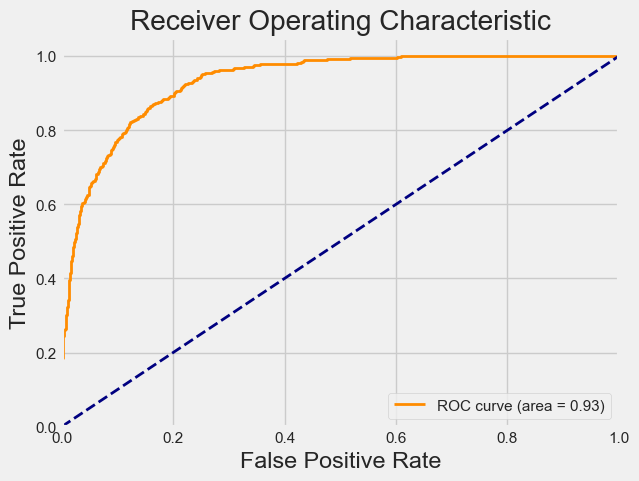

```
Training and evaluating base ExtraTrees with oversampling...

Results for  ExtraTrees:
	Optimal Threshold: 0.5000
	Classification Report:
               precision    recall  f1-score   support

           0       0.94      0.93      0.94      2072
           1       0.64      0.69      0.66       369

    accuracy                           0.89      2441
   macro avg       0.79      0.81      0.80      2441
weighted avg       0.90      0.89      0.90      2441

	ROC-AUC Score: 0.9186
	F1 Score: 0.6614
	G-mean: 0.7989
	Confusion Matrix:
 [[1929  143]
 [ 116  253]]
```

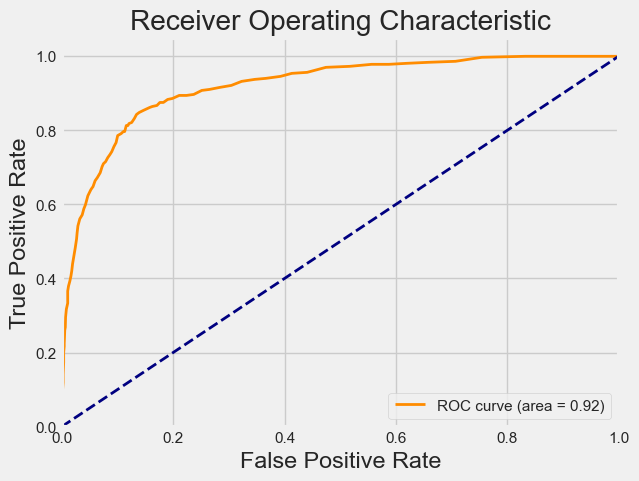

```
Training and evaluating base DecisionTree with oversampling...

Results for  DecisionTree:
	Optimal Threshold: 0.5000
	Classification Report:
               precision    recall  f1-score   support

           0       0.93      0.90      0.92      2072
           1       0.53      0.62      0.57       369

    accuracy                           0.86      2441
   macro avg       0.73      0.76      0.74      2441
weighted avg       0.87      0.86      0.86      2441

	ROC-AUC Score: 0.7597
	F1 Score: 0.5693
	G-mean: 0.7464
	Confusion Matrix:
 [[1868  204]
 [ 141  228]]
```

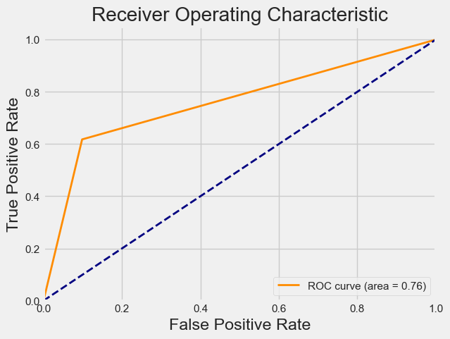

```python
oversampling_base_result = {}
for model_name, config in models.items():
    print(f"Training and evaluating base {model_name} with oversampling...")
    results = train_evaluate_model(
        model=config["base_model"],
        model_name=model_name,
        X_train=X_train_clf,
        y_train=y_train_clf,
        X_test=X_test_clf,
        y_test=y_test_clf,
        pipeline=ImbPipeline(steps=[
            ('smote', SMOTE(random_state=42)),
            ('model', config["base_model"])
        ])
    )
    oversampling_base_result[model_name] = results
```

##### *Tunned model*

```
Training and evaluating tuned RandomForest with oversampling...
Fitting 5 folds for each of 20 candidates, totalling 100 fits

Results for  RandomForest:
	Best Hyperparameters: {'model__bootstrap': True, 'model__class_weight': 'balanced_subsample', 'model__max_depth': 20, 'model__max_features': 'sqrt', 'model__min_samples_leaf': 5, 'model__min_samples_split': 15, 'model__n_estimators': 458}
	Optimal Threshold: 0.5000
	Classification Report:
               precision    recall  f1-score   support

           0       0.96      0.90      0.93      2072
           1       0.58      0.77      0.66       369

    accuracy                           0.88      2441
   macro avg       0.77      0.83      0.79      2441
weighted avg       0.90      0.88      0.89      2441

	ROC-AUC Score: 0.9302
	F1 Score: 0.6589
	G-mean: 0.8309
	Confusion Matrix:
 [[1865  207]
 [  86  283]]
```

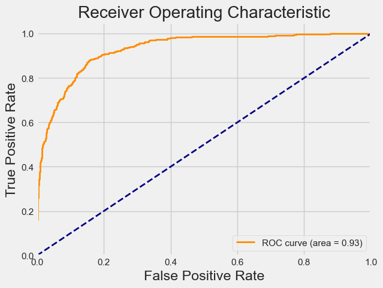

```
Training and evaluating tuned GradientBoosting with oversampling...
Fitting 5 folds for each of 20 candidates, totalling 100 fits

Results for  GradientBoosting:
	Best Hyperparameters: {'model__learning_rate': np.float64(0.023999698964084628), 'model__loss': 'exponential', 'model__max_depth': 9, 'model__max_features': 'log2', 'model__min_samples_leaf': 15, 'model__min_samples_split': 13, 'model__n_estimators': 154, 'model__subsample': np.float64(0.9916154429…
	Optimal Threshold: 0.5000
	Classification Report:
               precision    recall  f1-score   support

           0       0.95      0.91      0.93      2072
           1       0.59      0.75      0.66       369

    accuracy                           0.88      2441
   macro avg       0.77      0.83      0.80      2441
weighted avg       0.90      0.88      0.89      2441

	ROC-AUC Score: 0.9341
	F1 Score: 0.6627
	G-mean: 0.8247
	Confusion Matrix:
 [[1884  188]
 [  93  276]]
```

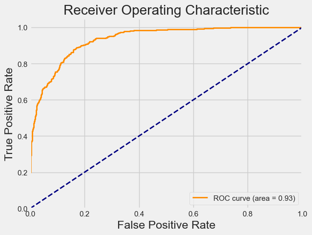

```
Training and evaluating tuned HistGradientBoosting with oversampling...
Fitting 5 folds for each of 20 candidates, totalling 100 fits

Results for  HistGradientBoosting:
	Best Hyperparameters: {'model__class_weight': 'balanced', 'model__early_stopping': 'auto', 'model__l2_regularization': np.float64(0.8021969807540397), 'model__learning_rate': np.float64(0.032365193103931246), 'model__max_bins': 120, 'model__max_depth': 3, 'model__max_iter': 443, 'model__max_leaf_no…
	Optimal Threshold: 0.5000
	Classification Report:
               precision    recall  f1-score   support

           0       0.95      0.92      0.94      2072
           1       0.62      0.75      0.68       369

    accuracy                           0.89      2441
   macro avg       0.79      0.83      0.81      2441
weighted avg       0.90      0.89      0.90      2441

	ROC-AUC Score: 0.9315
	F1 Score: 0.6765
	G-mean: 0.8284
	Confusion Matrix:
 [[1901  171]
 [  93  276]]
```

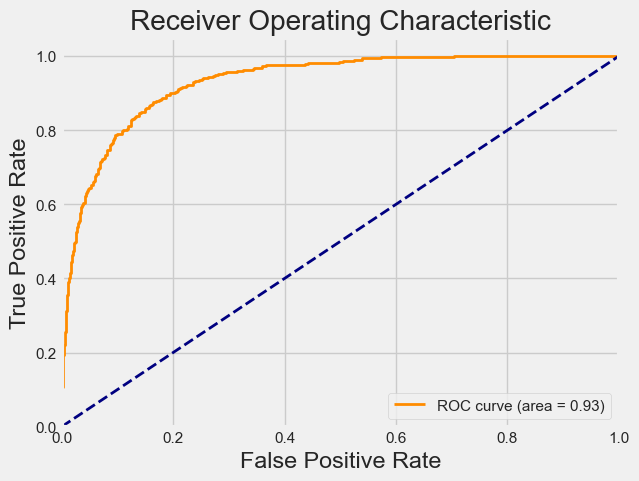

```
Training and evaluating tuned ExtraTrees with oversampling...
Fitting 5 folds for each of 20 candidates, totalling 100 fits

Results for  ExtraTrees:
	Best Hyperparameters: {'model__bootstrap': False, 'model__class_weight': 'balanced_subsample', 'model__max_depth': None, 'model__max_features': None, 'model__min_samples_leaf': 5, 'model__min_samples_split': 4, 'model__n_estimators': 271}
	Optimal Threshold: 0.5000
	Classification Report:
               precision    recall  f1-score   support

           0       0.96      0.90      0.92      2072
           1       0.57      0.77      0.65       369

    accuracy                           0.88      2441
   macro avg       0.76      0.83      0.79      2441
weighted avg       0.90      0.88      0.88      2441

	ROC-AUC Score: 0.9298
	F1 Score: 0.6536
	G-mean: 0.8303
	Confusion Matrix:
 [[1856  216]
 [  85  284]]
```

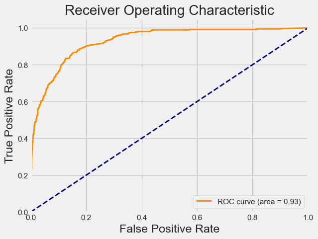

```
Training and evaluating tuned DecisionTree with oversampling...
Fitting 5 folds for each of 20 candidates, totalling 100 fits

Results for  DecisionTree:
	Best Hyperparameters: {'model__class_weight': 'balanced', 'model__criterion': 'gini', 'model__max_depth': 10, 'model__max_features': None, 'model__min_samples_leaf': 11, 'model__min_samples_split': 12, 'model__splitter': 'random'}
	Optimal Threshold: 0.5000
	Classification Report:
               precision    recall  f1-score   support

           0       0.95      0.88      0.91      2072
           1       0.52      0.77      0.62       369

    accuracy                           0.86      2441
   macro avg       0.74      0.82      0.77      2441
weighted avg       0.89      0.86      0.87      2441

	ROC-AUC Score: 0.8859
	F1 Score: 0.6220
	G-mean: 0.8194
	Confusion Matrix:
 [[1814  258]
 [  86  283]]
```

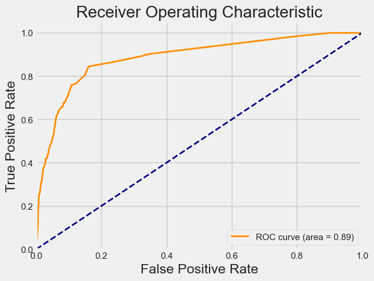

```python
oversampling_tunned_result = {}
for model_name, config in models.items():
    print(f"Training and evaluating tuned {model_name} with oversampling...")
    results = train_evaluate_model(
        model=config["base_model"],
        model_name=model_name,
        X_train=X_train_clf,
        y_train=y_train_clf,
        X_test=X_test_clf,
        y_test=y_test_clf,
        params={"model__" + key: value for key, value in config["params"].items()},
        pipeline=ImbPipeline(steps=[
            ('smote', SMOTE(random_state=42)),
            ('model', config["base_model"])
        ]),
        search=True,
    )
    oversampling_tunned_result[model_name] = results
```

#### **Hybrid sampling**

##### *Base model*

```
Training and evaluating base RandomForest with oversampling...

Results for  RandomForest:
	Optimal Threshold: 0.5000
	Classification Report:
               precision    recall  f1-score   support

           0       0.95      0.92      0.93      2072
           1       0.61      0.73      0.67       369

    accuracy                           0.89      2441
   macro avg       0.78      0.82      0.80      2441
weighted avg       0.90      0.89      0.89      2441

	ROC-AUC Score: 0.9255
	F1 Score: 0.6667
	G-mean: 0.8183
	Confusion Matrix:
 [[1903  169]
 [ 100  269]]
```

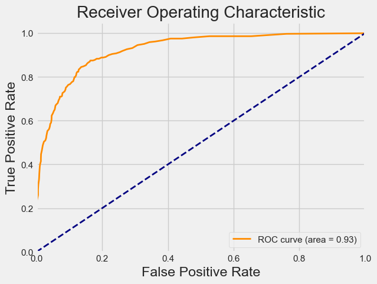

```
Training and evaluating base GradientBoosting with oversampling...

Results for  GradientBoosting:
	Optimal Threshold: 0.5000
	Classification Report:
               precision    recall  f1-score   support

           0       0.95      0.91      0.93      2072
           1       0.60      0.75      0.67       369

    accuracy                           0.89      2441
   macro avg       0.78      0.83      0.80      2441
weighted avg       0.90      0.89      0.89      2441

	ROC-AUC Score: 0.9307
	F1 Score: 0.6659
	G-mean: 0.8277
	Confusion Matrix:
 [[1884  188]
 [  91  278]]
```

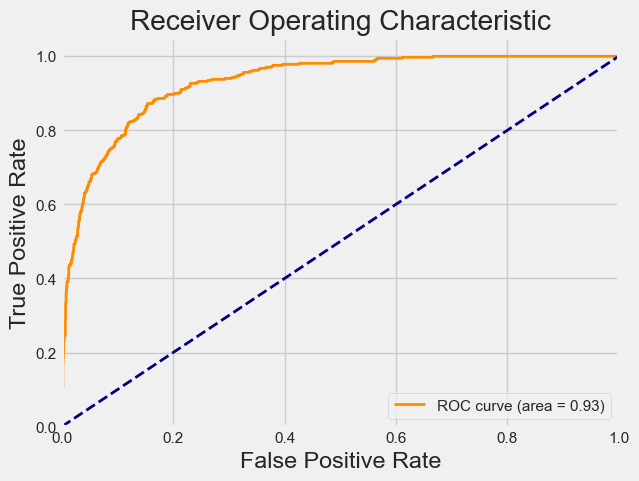

```
Training and evaluating base HistGradientBoosting with oversampling...

Results for  HistGradientBoosting:
	Optimal Threshold: 0.5000
	Classification Report:
               precision    recall  f1-score   support

           0       0.95      0.93      0.94      2072
           1       0.65      0.72      0.68       369

    accuracy                           0.90      2441
   macro avg       0.80      0.83      0.81      2441
weighted avg       0.90      0.90      0.90      2441

	ROC-AUC Score: 0.9354
	F1 Score: 0.6848
	G-mean: 0.8183
	Confusion Matrix:
 [[1932  140]
 [ 104  265]]
```

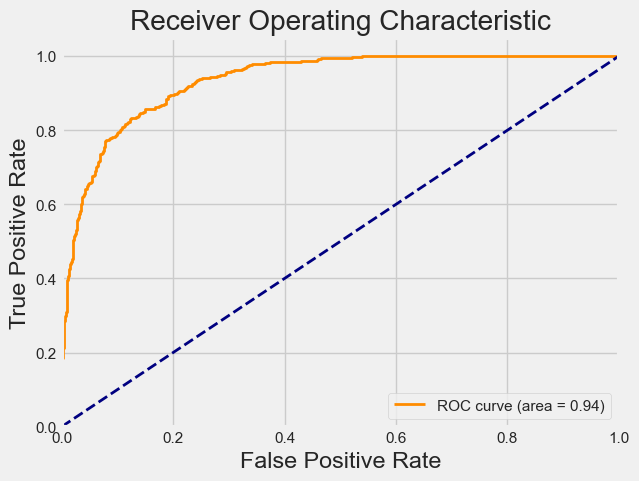

```
Training and evaluating base ExtraTrees with oversampling...

Results for  ExtraTrees:
	Optimal Threshold: 0.5000
	Classification Report:
               precision    recall  f1-score   support

           0       0.94      0.93      0.94      2072
           1       0.65      0.69      0.67       369

    accuracy                           0.90      2441
   macro avg       0.80      0.81      0.80      2441
weighted avg       0.90      0.90      0.90      2441

	ROC-AUC Score: 0.9187
	F1 Score: 0.6702
	G-mean: 0.8033
	Confusion Matrix:
 [[1935  137]
 [ 114  255]]
```

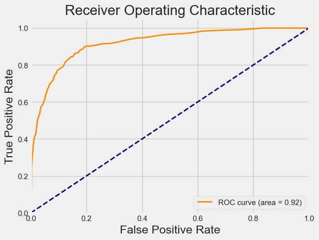

```
Training and evaluating base DecisionTree with oversampling...

Results for  DecisionTree:
	Optimal Threshold: 0.5000
	Classification Report:
               precision    recall  f1-score   support

           0       0.93      0.90      0.92      2072
           1       0.53      0.63      0.57       369

    accuracy                           0.86      2441
   macro avg       0.73      0.76      0.74      2441
weighted avg       0.87      0.86      0.86      2441

	ROC-AUC Score: 0.7631
	F1 Score: 0.5725
	G-mean: 0.7506
	Confusion Matrix:
 [[1865  207]
 [ 138  231]]
```

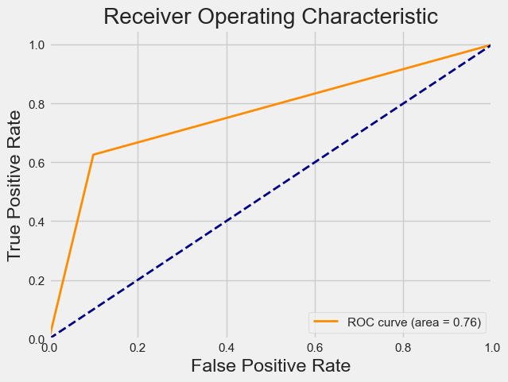

```python
hybrid_base_result = {}
for model_name, config in models.items():
    print(f"Training and evaluating base {model_name} with oversampling...")
    results = train_evaluate_model(
        model=config["base_model"],
        model_name=model_name,
        X_train=X_train_clf,
        y_train=y_train_clf,
        X_test=X_test_clf,
        y_test=y_test_clf,
        pipeline=ImbPipeline(steps=[
            ('smote', SMOTETomek(random_state=42)),
            ('model', config["base_model"])
        ])
    )
    hybrid_base_result[model_name] = results
```

##### *Tunned Model*

```
Training and evaluating tuned RandomForest with oversampling...
Fitting 5 folds for each of 20 candidates, totalling 100 fits

Results for  RandomForest:
	Best Hyperparameters: {'model__bootstrap': False, 'model__class_weight': 'balanced_subsample', 'model__max_depth': 30, 'model__max_features': 'log2', 'model__min_samples_leaf': 16, 'model__min_samples_split': 16, 'model__n_estimators': 314}
	Optimal Threshold: 0.5000
	Classification Report:
               precision    recall  f1-score   support

           0       0.96      0.89      0.93      2072
           1       0.57      0.78      0.66       369

    accuracy                           0.88      2441
   macro avg       0.76      0.84      0.79      2441
weighted avg       0.90      0.88      0.89      2441

	ROC-AUC Score: 0.9300
	F1 Score: 0.6583
	G-mean: 0.8357
	Confusion Matrix:
 [[1854  218]
 [  81  288]]
```

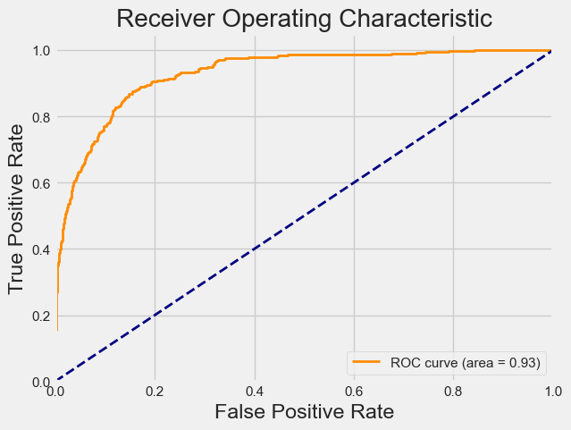

```
Training and evaluating tuned GradientBoosting with oversampling...
Fitting 5 folds for each of 20 candidates, totalling 100 fits

Results for  GradientBoosting:
	Best Hyperparameters: {'model__learning_rate': np.float64(0.023999698964084628), 'model__loss': 'exponential', 'model__max_depth': 9, 'model__max_features': 'log2', 'model__min_samples_leaf': 15, 'model__min_samples_split': 13, 'model__n_estimators': 154, 'model__subsample': np.float64(0.9916154429…
	Optimal Threshold: 0.5000
	Classification Report:
               precision    recall  f1-score   support

           0       0.95      0.91      0.93      2072
           1       0.59      0.76      0.67       369

    accuracy                           0.89      2441
   macro avg       0.77      0.83      0.80      2441
weighted avg       0.90      0.89      0.89      2441

	ROC-AUC Score: 0.9342
	F1 Score: 0.6659
	G-mean: 0.8287
	Confusion Matrix:
 [[1882  190]
 [  90  279]]
```

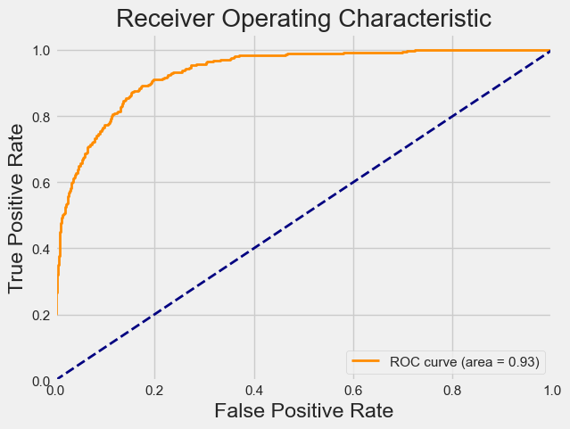

```
Training and evaluating tuned HistGradientBoosting with oversampling...
Fitting 5 folds for each of 20 candidates, totalling 100 fits

Results for  HistGradientBoosting:
	Best Hyperparameters: {'model__class_weight': 'balanced', 'model__early_stopping': 'auto', 'model__l2_regularization': np.float64(0.8021969807540397), 'model__learning_rate': np.float64(0.032365193103931246), 'model__max_bins': 120, 'model__max_depth': 3, 'model__max_iter': 443, 'model__max_leaf_no…
	Optimal Threshold: 0.5000
	Classification Report:
               precision    recall  f1-score   support

           0       0.95      0.92      0.93      2072
           1       0.61      0.74      0.67       369

    accuracy                           0.89      2441
   macro avg       0.78      0.83      0.80      2441
weighted avg       0.90      0.89      0.89      2441

	ROC-AUC Score: 0.9312
	F1 Score: 0.6707
	G-mean: 0.8247
	Confusion Matrix:
 [[1898  174]
 [  95  274]]
```

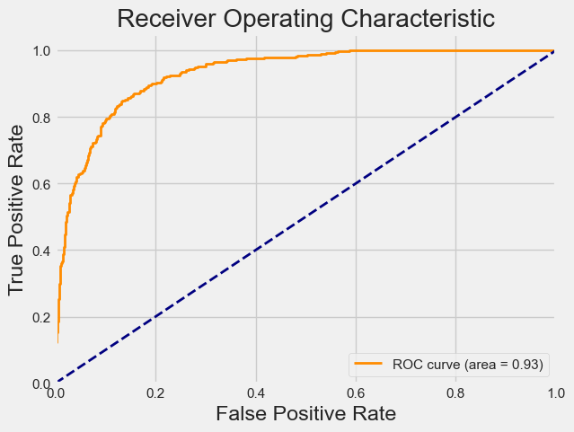

```
Training and evaluating tuned ExtraTrees with oversampling...
Fitting 5 folds for each of 20 candidates, totalling 100 fits

Results for  ExtraTrees:
	Best Hyperparameters: {'model__bootstrap': False, 'model__class_weight': 'balanced_subsample', 'model__max_depth': None, 'model__max_features': None, 'model__min_samples_leaf': 5, 'model__min_samples_split': 4, 'model__n_estimators': 271}
	Optimal Threshold: 0.5000
	Classification Report:
               precision    recall  f1-score   support

           0       0.96      0.89      0.92      2072
           1       0.56      0.77      0.65       369

    accuracy                           0.88      2441
   macro avg       0.76      0.83      0.79      2441
weighted avg       0.90      0.88      0.88      2441

	ROC-AUC Score: 0.9299
	F1 Score: 0.6514
	G-mean: 0.8306
	Confusion Matrix:
 [[1851  221]
 [  84  285]]
```

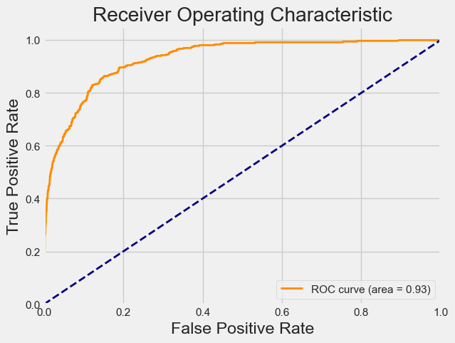

```
Training and evaluating tuned DecisionTree with oversampling...
Fitting 5 folds for each of 20 candidates, totalling 100 fits

Results for  DecisionTree:
	Best Hyperparameters: {'model__class_weight': 'balanced', 'model__criterion': 'gini', 'model__max_depth': 10, 'model__max_features': None, 'model__min_samples_leaf': 11, 'model__min_samples_split': 12, 'model__splitter': 'random'}
	Optimal Threshold: 0.5000
	Classification Report:
               precision    recall  f1-score   support

           0       0.95      0.89      0.92      2072
           1       0.54      0.74      0.63       369

    accuracy                           0.87      2441
   macro avg       0.75      0.82      0.77      2441
weighted avg       0.89      0.87      0.88      2441

	ROC-AUC Score: 0.8885
	F1 Score: 0.6284
	G-mean: 0.8127
	Confusion Matrix:
 [[1843  229]
 [  95  274]]
```

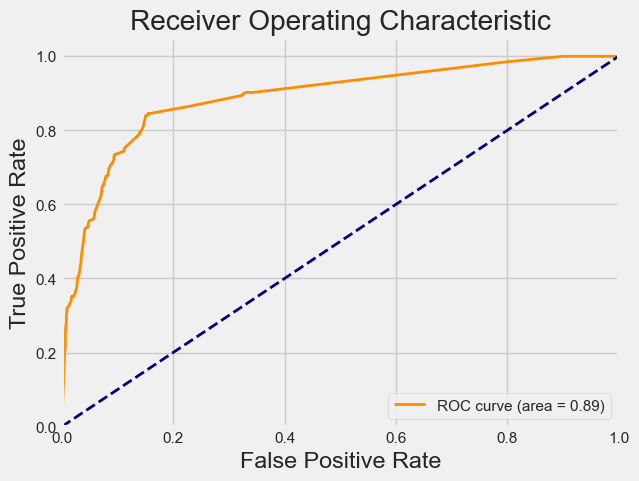

```python
hybridsampling_tunned_result = {}
for model_name, config in models.items():
    print(f"Training and evaluating tuned {model_name} with oversampling...")
    results = train_evaluate_model(
        model=config["base_model"],
        model_name = model_name,
        X_train=X_train_clf,
        y_train=y_train_clf,
        X_test=X_test_clf,
        y_test=y_test_clf,
        params={"model__" + key: value for key, value in config["params"].items()},
        pipeline=ImbPipeline(steps=[
            ('smote', SMOTETomek(random_state=42)),
            ('model', config["base_model"])
        ]),
        search=True,
    )
    hybridsampling_tunned_result[model_name] = results
```

### **Algorithmic Level**

#### **Threshold method**

##### *Base model*

```
Training and evaluating base RandomForest with threshold...

Results for  RandomForest:
	Optimal Threshold: 0.3535
	Classification Report:
               precision    recall  f1-score   support

           0       0.95      0.92      0.94      2072
           1       0.62      0.75      0.68       369

    accuracy                           0.89      2441
   macro avg       0.79      0.83      0.81      2441
weighted avg       0.90      0.89      0.90      2441

	ROC-AUC Score: 0.9262
	F1 Score: 0.6765
	G-mean: 0.8284
	Confusion Matrix:
 [[1901  171]
 [  93  276]]
```

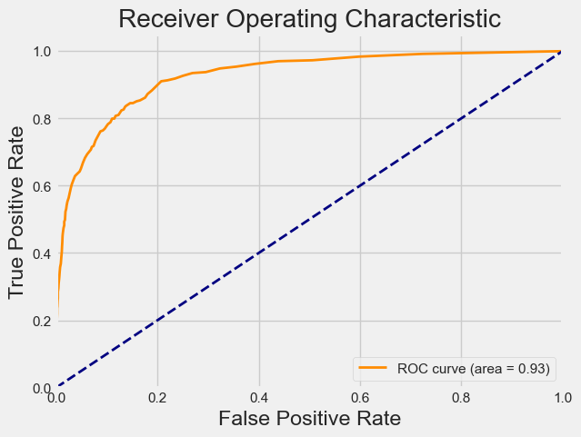

```
Training and evaluating base GradientBoosting with threshold...

Results for  GradientBoosting:
	Optimal Threshold: 0.3421
	Classification Report:
               precision    recall  f1-score   support

           0       0.95      0.93      0.94      2072
           1       0.64      0.75      0.69       369

    accuracy                           0.90      2441
   macro avg       0.80      0.84      0.82      2441
weighted avg       0.91      0.90      0.90      2441

	ROC-AUC Score: 0.9353
	F1 Score: 0.6941
	G-mean: 0.8351
	Confusion Matrix:
 [[1918  154]
 [  91  278]]
```

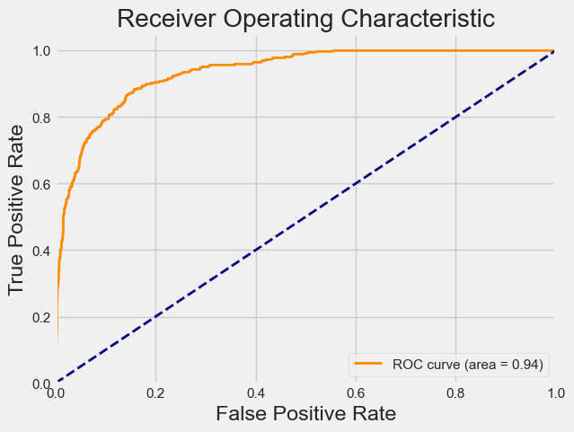

```
Training and evaluating base HistGradientBoosting with threshold...

Results for  HistGradientBoosting:
	Optimal Threshold: 0.2516
	Classification Report:
               precision    recall  f1-score   support

           0       0.96      0.90      0.93      2072
           1       0.59      0.80      0.68       369

    accuracy                           0.88      2441
   macro avg       0.77      0.85      0.80      2441
weighted avg       0.90      0.88      0.89      2441

	ROC-AUC Score: 0.9378
	F1 Score: 0.6751
	G-mean: 0.8466
	Confusion Matrix:
 [[1864  208]
 [  75  294]]
```

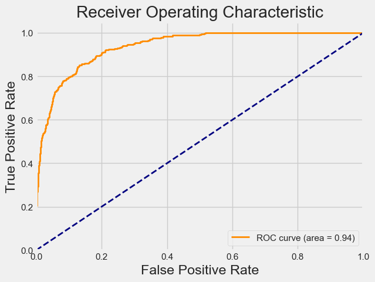

```
Training and evaluating base ExtraTrees with threshold...

Results for  ExtraTrees:
	Optimal Threshold: 0.2871
	Classification Report:
               precision    recall  f1-score   support

           0       0.96      0.90      0.93      2072
           1       0.58      0.78      0.67       369

    accuracy                           0.88      2441
   macro avg       0.77      0.84      0.80      2441
weighted avg       0.90      0.88      0.89      2441

	ROC-AUC Score: 0.9195
	F1 Score: 0.6682
	G-mean: 0.8396
	Confusion Matrix:
 [[1865  207]
 [  80  289]]
```

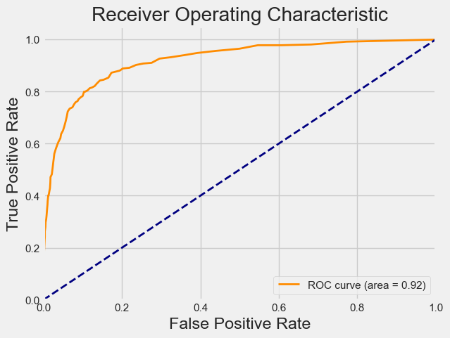

```
Training and evaluating base DecisionTree with threshold...

Results for  DecisionTree:
	Optimal Threshold: 0.0101
	Classification Report:
               precision    recall  f1-score   support

           0       0.93      0.91      0.92      2072
           1       0.55      0.59      0.57       369

    accuracy                           0.87      2441
   macro avg       0.74      0.75      0.74      2441
weighted avg       0.87      0.87      0.87      2441

	ROC-AUC Score: 0.7513
	F1 Score: 0.5688
	G-mean: 0.7334
	Confusion Matrix:
 [[1895  177]
 [ 152  217]]
```

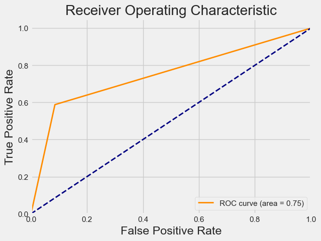

```python
threshold_base_results = {}
for model_name, config in models.items():
    print(f"Training and evaluating base {model_name} with threshold...")
    results = train_evaluate_model(
        model=config["base_model"],
        model_name = model_name,
        X_train=X_train_clf,
        y_train=y_train_clf,
        X_test=X_test_clf,
        y_test=y_test_clf,
        threshold=True  # Enable threshold optimization
    )
    threshold_base_results[model_name] = results
```